# Customer Analytics

### It containes three parts:

##### 1.Segmentation of Customers

##### 2.Analysis of the Segmented Customers

##### 3.Predictive Analysis

##### 3.1 Price Elasticity of Purchase Probability

##### 3.2 Price Elasticity of Brand Choice Probability

##### 3.3 Price Elasticity of Purchase Quantity

### Import Libraries

```python
import pandas as pd
import numpy as np
import seaborn as sns
import matplotlib.pyplot as plt
```

```python
from sklearn.preprocessing import StandardScaler
```

```python
from scipy.cluster.hierarchy  import dendrogram,linkage
```

```python
from sklearn.cluster import KMeans
```

```python
from sklearn.decomposition import PCA
```

```python
import pickle
```

```python
import warnings
warnings.filterwarnings('ignore')
```

```python
from sklearn.linear_model import LinearRegression
from sklearn.linear_model import LogisticRegression
```

### Import Data

[figure not shown]

# Customer Segementation

## Customer Data

```python
df=pd.read_csv('segmentation data.csv')
```

```python
df.head()
```

|  | ID | Sex | Marital status | Age | Education | Income | Occupation | Settlement size |
| --- | --- | --- | --- | --- | --- | --- | --- | --- |
| 0 | 100000001 | 0 | 0 | 67 | 2 | 124670 | 1 | 2 |
| 1 | 100000002 | 1 | 1 | 22 | 1 | 150773 | 1 | 2 |
| 2 | 100000003 | 0 | 0 | 49 | 1 | 89210 | 0 | 0 |
| 3 | 100000004 | 0 | 0 | 45 | 1 | 171565 | 1 | 1 |
| 4 | 100000005 | 0 | 0 | 53 | 1 | 149031 | 1 | 1 |

### EDA

```python
df.shape
```

```
(2000, 8)
```

```python
df.isnull().sum()
```

```
ID                 0
Sex                0
Marital status     0
Age                0
Education          0
Income             0
Occupation         0
Settlement size    0
dtype: int64
```

```python
df.drop('ID',axis=1,inplace=True)
```

```python
df.head()
```

|  | Sex | Marital status | Age | Education | Income | Occupation | Settlement size |
| --- | --- | --- | --- | --- | --- | --- | --- |
| 0 | 0 | 0 | 67 | 2 | 124670 | 1 | 2 |
| 1 | 1 | 1 | 22 | 1 | 150773 | 1 | 2 |
| 2 | 0 | 0 | 49 | 1 | 89210 | 0 | 0 |
| 3 | 0 | 0 | 45 | 1 | 171565 | 1 | 1 |
| 4 | 0 | 0 | 53 | 1 | 149031 | 1 | 1 |

```python
df.describe()
```

|  | Sex | Marital status | Age | Education | Income | Occupation | Settlement size |
| --- | --- | --- | --- | --- | --- | --- | --- |
| count | 2000.000000 | 2000.000000 | 2000.000000 | 2000.00000 | 2000.000000 | 2000.000000 | 2000.000000 |
| mean | 0.457000 | 0.496500 | 35.909000 | 1.03800 | 120954.419000 | 0.810500 | 0.739000 |
| std | 0.498272 | 0.500113 | 11.719402 | 0.59978 | 38108.824679 | 0.638587 | 0.812533 |
| min | 0.000000 | 0.000000 | 18.000000 | 0.00000 | 35832.000000 | 0.000000 | 0.000000 |
| 25% | 0.000000 | 0.000000 | 27.000000 | 1.00000 | 97663.250000 | 0.000000 | 0.000000 |
| 50% | 0.000000 | 0.000000 | 33.000000 | 1.00000 | 115548.500000 | 1.000000 | 1.000000 |
| 75% | 1.000000 | 1.000000 | 42.000000 | 1.00000 | 138072.250000 | 1.000000 | 1.000000 |
| max | 1.000000 | 1.000000 | 76.000000 | 3.00000 | 309364.000000 | 2.000000 | 2.000000 |

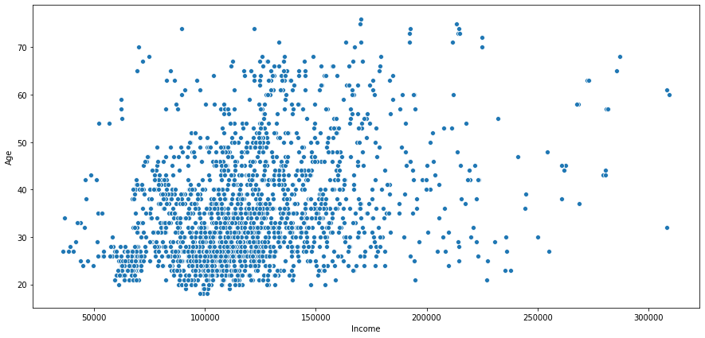

```python
plt.figure(figsize=(15,7))
sns.scatterplot(x='Income',y='Age',data=df)
```

### Scaling The Data

```python
sc=StandardScaler()
```

```python
x=df
x.head()
```

|  | Sex | Marital status | Age | Education | Income | Occupation | Settlement size |
| --- | --- | --- | --- | --- | --- | --- | --- |
| 0 | 0 | 0 | 67 | 2 | 124670 | 1 | 2 |
| 1 | 1 | 1 | 22 | 1 | 150773 | 1 | 2 |
| 2 | 0 | 0 | 49 | 1 | 89210 | 0 | 0 |
| 3 | 0 | 0 | 45 | 1 | 171565 | 1 | 1 |
| 4 | 0 | 0 | 53 | 1 | 149031 | 1 | 1 |

```python
x_standard=sc.fit_transform(x)
x_standard
```

```
array([[-0.91739884, -0.99302433,  2.65361447, ...,  0.09752361,
         0.29682303,  1.552326  ],
       [ 1.09003844,  1.00702467, -1.18713209, ...,  0.78265438,
         0.29682303,  1.552326  ],
       [-0.91739884, -0.99302433,  1.11731585, ..., -0.83320224,
        -1.26952539, -0.90972951],
       ...,
       [-0.91739884, -0.99302433, -0.41898277, ..., -0.90695688,
        -1.26952539, -0.90972951],
       [ 1.09003844,  1.00702467, -1.01643224, ..., -0.60332923,
        -1.26952539, -0.90972951],
       [-0.91739884, -0.99302433, -0.93108232, ..., -1.3789866 ,
        -1.26952539, -0.90972951]])
```

## Applying Clustering Techniques

### Hierarchical Clustering

```python
hier_cluster=linkage(x_standard,method='ward')
```

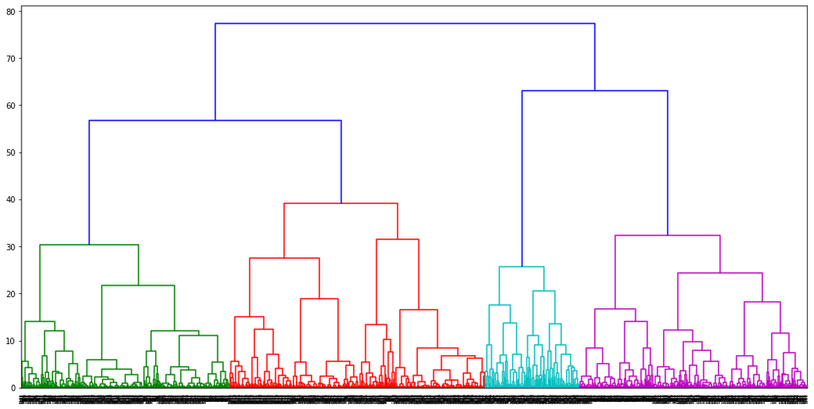

```python
plt.figure(figsize = (18,9))
dendrogram(hier_cluster)
plt.show()
```

### KMeans Clustering

```python
sse=[]
for i in range(1,10):
    km=KMeans(n_clusters=i)
    km.fit_predict(x_standard)
    a=km.inertia_
    sse.append(a)
```

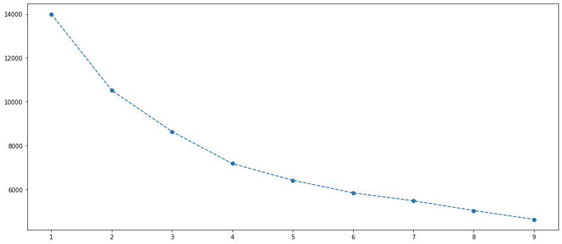

```python
p=range(1,10)
plt.figure(figsize=(16,7))
plt.plot(p,sse,marker = 'o', linestyle = '--')
plt.show()
```

### It can be seen from the graph that min cluster is 4.

```python
km=KMeans(n_clusters=4)
prediction=km.fit_predict(x_standard)
```

```python
km_normal=df.copy()
```

```python
km_normal['cluster']=prediction
```

```python
km_normal.head()
```

|  | Sex | Marital status | Age | Education | Income | Occupation | Settlement size | cluster |
| --- | --- | --- | --- | --- | --- | --- | --- | --- |
| 0 | 0 | 0 | 67 | 2 | 124670 | 1 | 2 | 3 |
| 1 | 1 | 1 | 22 | 1 | 150773 | 1 | 2 | 0 |
| 2 | 0 | 0 | 49 | 1 | 89210 | 0 | 0 | 2 |
| 3 | 0 | 0 | 45 | 1 | 171565 | 1 | 1 | 1 |
| 4 | 0 | 0 | 53 | 1 | 149031 | 1 | 1 | 1 |

```python
df1=km_normal[km_normal['cluster']==0]
df2=km_normal[km_normal['cluster']==1]
df3=km_normal[km_normal['cluster']==2]
df4=km_normal[km_normal['cluster']==3]
```

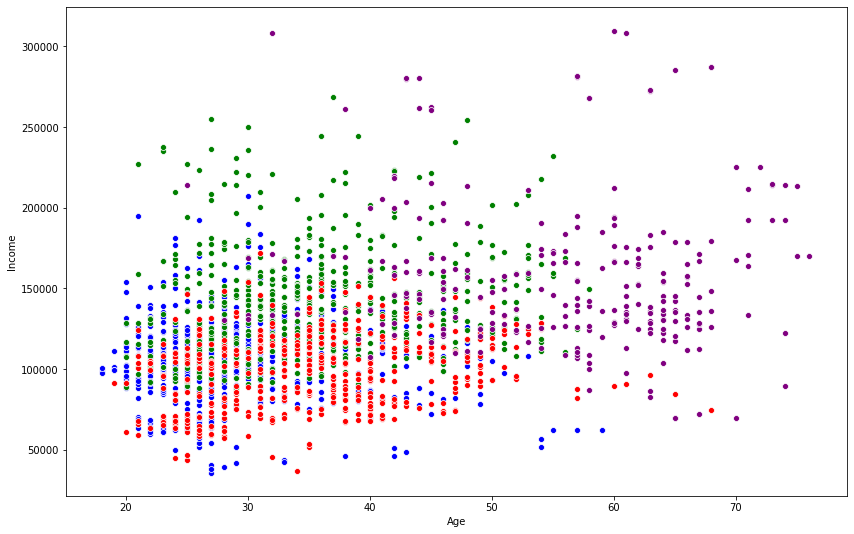

```python
plt.figure(figsize=(14,9))
sns.scatterplot(x='Age',y='Income',data=df1,color='blue')
sns.scatterplot(x='Age',y='Income',data=df2,color='green')
sns.scatterplot(x='Age',y='Income',data=df3,color='red')
sns.scatterplot(x='Age',y='Income',data=df4,color='purple')
plt.show()
```

Mostly the segments are overlapping

## PCA

```python
pca=PCA()
```

```python
pca.fit(x_standard)
```

```
PCA(copy=True, iterated_power='auto', n_components=None, random_state=None,
    svd_solver='auto', tol=0.0, whiten=False)
```

### Checking how many features to select

```python
var=pca.explained_variance_ratio_
var
```

```
array([0.35696328, 0.26250923, 0.18821114, 0.0755775 , 0.05716512,
       0.03954794, 0.02002579])
```

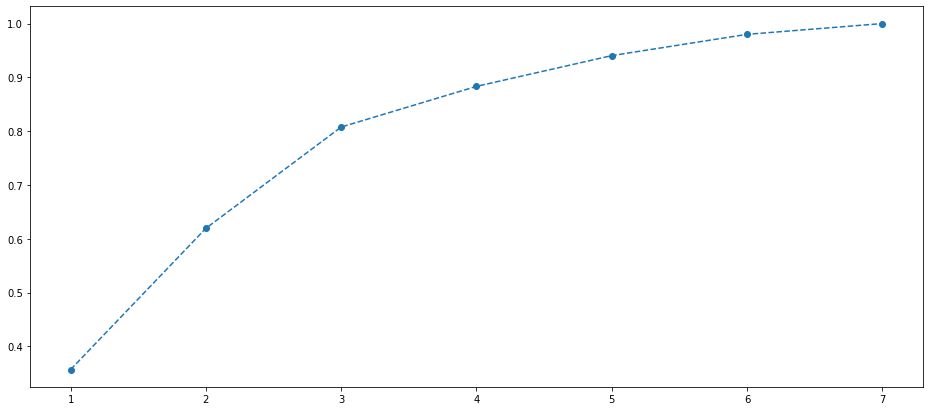

```python
p=range(1,8)
plt.figure(figsize=(16,7))
plt.plot(p,var.cumsum(),marker = 'o', linestyle = '--')
plt.show()
```

```python
pca=PCA(n_components=3)
```

```python
pca_data=pca.fit(x_standard)
```

```python
new_data=pca.transform(x_standard)
```

```python
new_data
```

```
array([[ 2.51474593,  0.83412239,  2.1748059 ],
       [ 0.34493528,  0.59814564, -2.21160279],
       [-0.65106267, -0.68009318,  2.2804186 ],
       ...,
       [-1.45229829, -2.23593665,  0.89657125],
       [-2.24145254,  0.62710847, -0.53045631],
       [-1.86688505, -2.45467234,  0.66262172]])
```

```python
new_data.shape
```

```
(2000, 3)
```

```python
pca_df=pd.DataFrame(new_data,columns=['component1','component2','component3'])
pca_df
```

|  | component1 | component2 | component3 |
| --- | --- | --- | --- |
| 0 | 2.514746 | 0.834122 | 2.174806 |
| 1 | 0.344935 | 0.598146 | -2.211603 |
| 2 | -0.651063 | -0.680093 | 2.280419 |
| 3 | 1.714316 | -0.579927 | 0.730731 |
| 4 | 1.626745 | -0.440496 | 1.244909 |
| ... | ... | ... | ... |
| 1995 | -0.866034 | 0.298330 | 1.438958 |
| 1996 | -1.114957 | 0.794727 | -1.079871 |
| 1997 | -1.452298 | -2.235937 | 0.896571 |
| 1998 | -2.241453 | 0.627108 | -0.530456 |
| 1999 | -1.866885 | -2.454672 | 0.662622 |

2000 rows × 3 columns

### K-means clustering with PCA

```python
sse=[]
for i in range(1,10):
    km=KMeans(n_clusters=i)
    km.fit_predict(new_data)
    a=km.inertia_
    sse.append(a)
```

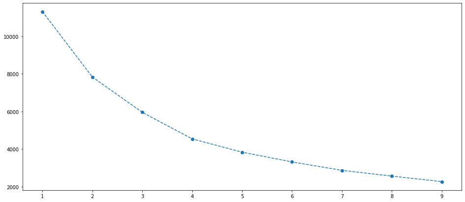

```python
p=range(1,10)
plt.figure(figsize=(16,7))
plt.plot(p,sse,marker = 'o', linestyle = '--')
plt.show()
```

```python
km=KMeans(n_clusters=4)
prediction=km.fit_predict(new_data)
```

```python
prediction
```

```
array([2, 1, 0, ..., 0, 1, 0], dtype=int32)
```

```python
pca_df['cluster']=prediction
```

```python
pca_df.head()
```

|  | component1 | component2 | component3 | cluster |
| --- | --- | --- | --- | --- |
| 0 | 2.514746 | 0.834122 | 2.174806 | 2 |
| 1 | 0.344935 | 0.598146 | -2.211603 | 1 |
| 2 | -0.651063 | -0.680093 | 2.280419 | 0 |
| 3 | 1.714316 | -0.579927 | 0.730731 | 3 |
| 4 | 1.626745 | -0.440496 | 1.244909 | 3 |

```python
df1=pca_df[pca_df['cluster']==0]
df2=pca_df[pca_df['cluster']==1]
df3=pca_df[pca_df['cluster']==2]
df4=pca_df[pca_df['cluster']==3]
```

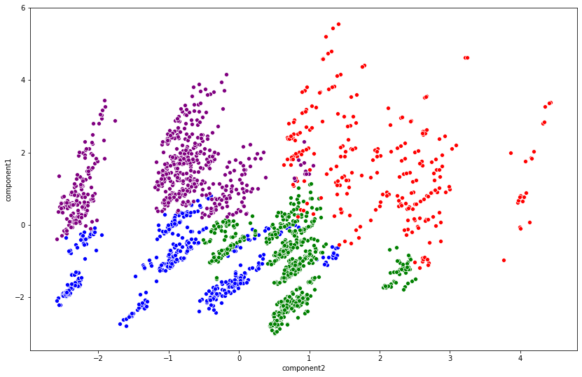

```python
plt.figure(figsize=(14,9))
sns.scatterplot(x='component2',y='component1',data=df1,color='blue')
sns.scatterplot(x='component2',y='component1',data=df2,color='green')
sns.scatterplot(x='component2',y='component1',data=df3,color='red')
sns.scatterplot(x='component2',y='component1',data=df4,color='purple')
plt.show()
```

### Now we can distinguish the clusters

### Saving the customer model

```python
with open('scaler.pickle','wb') as f:
    pickle.dump(sc,f)
```

```python
with open('pca.pickle','wb') as f:
    pickle.dump(pca,f)
```

```python
with open('kmeans.pickle','wb') as f:
    pickle.dump(km,f)
```

## Completed customer segmentation Based on their features

### Loading Customer Purchase Data

[figure not shown]

```python
purchase_df=pd.read_csv('purchase data.csv')
```

```python
purchase_df.head()
```

|  | ID | Day | Incidence | Brand | Quantity | Last_Inc_Brand | Last_Inc_Quantity | Price_1 | Price_2 | Price_3 | ... | Promotion_3 | Promotion_4 | Promotion_5 | Sex | Marital status | Age | Education | Income | Occupation | Settlement size |
| --- | --- | --- | --- | --- | --- | --- | --- | --- | --- | --- | --- | --- | --- | --- | --- | --- | --- | --- | --- | --- | --- |
| 0 | 200000001 | 1 | 0 | 0 | 0 | 0 | 0 | 1.59 | 1.87 | 2.01 | ... | 0 | 0 | 0 | 0 | 0 | 47 | 1 | 110866 | 1 | 0 |
| 1 | 200000001 | 11 | 0 | 0 | 0 | 0 | 0 | 1.51 | 1.89 | 1.99 | ... | 0 | 0 | 0 | 0 | 0 | 47 | 1 | 110866 | 1 | 0 |
| 2 | 200000001 | 12 | 0 | 0 | 0 | 0 | 0 | 1.51 | 1.89 | 1.99 | ... | 0 | 0 | 0 | 0 | 0 | 47 | 1 | 110866 | 1 | 0 |
| 3 | 200000001 | 16 | 0 | 0 | 0 | 0 | 0 | 1.52 | 1.89 | 1.98 | ... | 0 | 0 | 0 | 0 | 0 | 47 | 1 | 110866 | 1 | 0 |
| 4 | 200000001 | 18 | 0 | 0 | 0 | 0 | 0 | 1.52 | 1.89 | 1.99 | ... | 0 | 0 | 0 | 0 | 0 | 47 | 1 | 110866 | 1 | 0 |

5 rows × 24 columns

```python
purchase_df.shape
```

```
(58693, 24)
```

```python
purchase_df.columns
```

```
Index(['ID', 'Day', 'Incidence', 'Brand', 'Quantity', 'Last_Inc_Brand',
       'Last_Inc_Quantity', 'Price_1', 'Price_2', 'Price_3', 'Price_4',
       'Price_5', 'Promotion_1', 'Promotion_2', 'Promotion_3', 'Promotion_4',
       'Promotion_5', 'Sex', 'Marital status', 'Age', 'Education', 'Income',
       'Occupation', 'Settlement size'],
      dtype='object')
```

```python
purchase_df.isnull().sum()
```

```
ID                   0
Day                  0
Incidence            0
Brand                0
Quantity             0
Last_Inc_Brand       0
Last_Inc_Quantity    0
Price_1              0
Price_2              0
Price_3              0
Price_4              0
Price_5              0
Promotion_1          0
Promotion_2          0
Promotion_3          0
Promotion_4          0
Promotion_5          0
Sex                  0
Marital status       0
Age                  0
Education            0
Income               0
Occupation           0
Settlement size      0
dtype: int64
```

### Loading Models

```python
with open('scaler.pickle','rb') as f:
    sc=pickle.load(f)
```

```python
with open('kmeans.pickle','rb') as f:
    km=pickle.load(f)
```

```python
with open('pca.pickle','rb') as f:
    pca=pickle.load(f)
```

### Using this model on purchase data set

```python
features=purchase_df[['Sex', 'Marital status', 'Age', 'Education', 'Income', 'Occupation', 'Settlement size']]
features.head()
```

|  | Sex | Marital status | Age | Education | Income | Occupation | Settlement size |
| --- | --- | --- | --- | --- | --- | --- | --- |
| 0 | 0 | 0 | 47 | 1 | 110866 | 1 | 0 |
| 1 | 0 | 0 | 47 | 1 | 110866 | 1 | 0 |
| 2 | 0 | 0 | 47 | 1 | 110866 | 1 | 0 |
| 3 | 0 | 0 | 47 | 1 | 110866 | 1 | 0 |
| 4 | 0 | 0 | 47 | 1 | 110866 | 1 | 0 |

### Scaling

```python
purchase_standard=sc.transform(features)
```

### PCA

```python
purchase_pca=pca.transform(purchase_standard)
```

### Applying Kmeans

```python
prediction=km.predict(purchase_pca)
```

```python
prediction
```

```
array([0, 0, 0, ..., 0, 0, 0], dtype=int32)
```

```python
purchase_df['segment']=prediction
```

```python
purchase_df.head()
```

|  | ID | Day | Incidence | Brand | Quantity | Last_Inc_Brand | Last_Inc_Quantity | Price_1 | Price_2 | Price_3 | ... | Promotion_4 | Promotion_5 | Sex | Marital status | Age | Education | Income | Occupation | Settlement size | segment |
| --- | --- | --- | --- | --- | --- | --- | --- | --- | --- | --- | --- | --- | --- | --- | --- | --- | --- | --- | --- | --- | --- |
| 0 | 200000001 | 1 | 0 | 0 | 0 | 0 | 0 | 1.59 | 1.87 | 2.01 | ... | 0 | 0 | 0 | 0 | 47 | 1 | 110866 | 1 | 0 | 0 |
| 1 | 200000001 | 11 | 0 | 0 | 0 | 0 | 0 | 1.51 | 1.89 | 1.99 | ... | 0 | 0 | 0 | 0 | 47 | 1 | 110866 | 1 | 0 | 0 |
| 2 | 200000001 | 12 | 0 | 0 | 0 | 0 | 0 | 1.51 | 1.89 | 1.99 | ... | 0 | 0 | 0 | 0 | 47 | 1 | 110866 | 1 | 0 | 0 |
| 3 | 200000001 | 16 | 0 | 0 | 0 | 0 | 0 | 1.52 | 1.89 | 1.98 | ... | 0 | 0 | 0 | 0 | 47 | 1 | 110866 | 1 | 0 | 0 |
| 4 | 200000001 | 18 | 0 | 0 | 0 | 0 | 0 | 1.52 | 1.89 | 1.99 | ... | 0 | 0 | 0 | 0 | 47 | 1 | 110866 | 1 | 0 | 0 |

5 rows × 25 columns

```python
purchase_df['segment'].value_counts()
```

```
0    21495
3    13580
1    12123
2    11495
Name: segment, dtype: int64
```

### Applied the segmentation model on purchase dataset

```python
purchase_df.head()
```

|  | ID | Day | Incidence | Brand | Quantity | Last_Inc_Brand | Last_Inc_Quantity | Price_1 | Price_2 | Price_3 | ... | Promotion_4 | Promotion_5 | Sex | Marital status | Age | Education | Income | Occupation | Settlement size | segment |
| --- | --- | --- | --- | --- | --- | --- | --- | --- | --- | --- | --- | --- | --- | --- | --- | --- | --- | --- | --- | --- | --- |
| 0 | 200000001 | 1 | 0 | 0 | 0 | 0 | 0 | 1.59 | 1.87 | 2.01 | ... | 0 | 0 | 0 | 0 | 47 | 1 | 110866 | 1 | 0 | 0 |
| 1 | 200000001 | 11 | 0 | 0 | 0 | 0 | 0 | 1.51 | 1.89 | 1.99 | ... | 0 | 0 | 0 | 0 | 47 | 1 | 110866 | 1 | 0 | 0 |
| 2 | 200000001 | 12 | 0 | 0 | 0 | 0 | 0 | 1.51 | 1.89 | 1.99 | ... | 0 | 0 | 0 | 0 | 47 | 1 | 110866 | 1 | 0 | 0 |
| 3 | 200000001 | 16 | 0 | 0 | 0 | 0 | 0 | 1.52 | 1.89 | 1.98 | ... | 0 | 0 | 0 | 0 | 47 | 1 | 110866 | 1 | 0 | 0 |
| 4 | 200000001 | 18 | 0 | 0 | 0 | 0 | 0 | 1.52 | 1.89 | 1.99 | ... | 0 | 0 | 0 | 0 | 47 | 1 | 110866 | 1 | 0 | 0 |

5 rows × 25 columns

# Purchase Analysis

## Data Analysis on purchase of customers

### Checking how many times a customer visits the store and number of times he buys something

```python
#No of visits
temp=purchase_df.groupby('ID')['Day'].count()
temp1=pd.DataFrame(temp)
```

```python
temp1=temp1.rename(columns={'Day':'n_vists'})
temp1.head()
```

| ID | n_vists |
| --- | --- |
| 200000001 | 101 |
| 200000002 | 87 |
| 200000003 | 97 |
| 200000004 | 85 |
| 200000005 | 111 |

```python
# No of times he buys
temp=purchase_df.groupby('ID')['Incidence'].sum()
temp
```

```
ID
200000001     9
200000002    11
200000003    10
200000004    11
200000005    13
             ..
200000496    20
200000497    43
200000498    39
200000499    31
200000500    15
Name: Incidence, Length: 500, dtype: int64
```

```python
temp1['n_purchase']=temp
```

```python
temp1.head()
```

| ID | n_vists | n_purchase |
| --- | --- | --- |
| 200000001 | 101 | 9 |
| 200000002 | 87 | 11 |
| 200000003 | 97 | 10 |
| 200000004 | 85 | 11 |
| 200000005 | 111 | 13 |

### Checking the avg purchase

```python
a=temp1['n_purchase']/temp1['n_vists']
a
```

```
ID
200000001    0.089109
200000002    0.126437
200000003    0.103093
200000004    0.129412
200000005    0.117117
               ...
200000496    0.166667
200000497    0.358333
200000498    0.297710
200000499    0.292453
200000500    0.120968
Length: 500, dtype: float64
```

```python
temp1['avg_purchase']=a
temp1.head()
```

| ID | n_vists | n_purchase | avg_purchase |
| --- | --- | --- | --- |
| 200000001 | 101 | 9 | 0.089109 |
| 200000002 | 87 | 11 | 0.126437 |
| 200000003 | 97 | 10 | 0.103093 |
| 200000004 | 85 | 11 | 0.129412 |
| 200000005 | 111 | 13 | 0.117117 |

### Dividing each customer into segments

```python
a=purchase_df.groupby('ID')['segment'].mean()
a
```

```
ID
200000001    0
200000002    2
200000003    0
200000004    0
200000005    3
            ..
200000496    1
200000497    0
200000498    1
200000499    0
200000500    0
Name: segment, Length: 500, dtype: int32
```

```python
temp1['segment']=a
temp1.head()
```

| ID | n_vists | n_purchase | avg_purchase | segment |
| --- | --- | --- | --- | --- |
| 200000001 | 101 | 9 | 0.089109 | 0 |
| 200000002 | 87 | 11 | 0.126437 | 2 |
| 200000003 | 97 | 10 | 0.103093 | 0 |
| 200000004 | 85 | 11 | 0.129412 | 0 |
| 200000005 | 111 | 13 | 0.117117 | 3 |

## Data analysis of each customer segmemts

### Calculating no of customers in each segment

```python
n=temp1.shape[0]
```

```python
percent=temp1['segment'].value_counts()/n*100
percent
```

```
0    37.8
3    22.0
1    20.6
2    19.6
Name: segment, dtype: float64
```

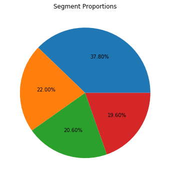

```python
plt.figure(figsize=(10,6))
plt.pie(percent,autopct='%1.2f%%')
plt.title('Segment Proportions')
plt.show()
```

### Number of visits by each segment

```python
a=temp1.groupby('segment')['n_vists'].mean()
a
```

```
segment
0    113.730159
1    117.699029
2    117.295918
3    123.454545
Name: n_vists, dtype: float64
```

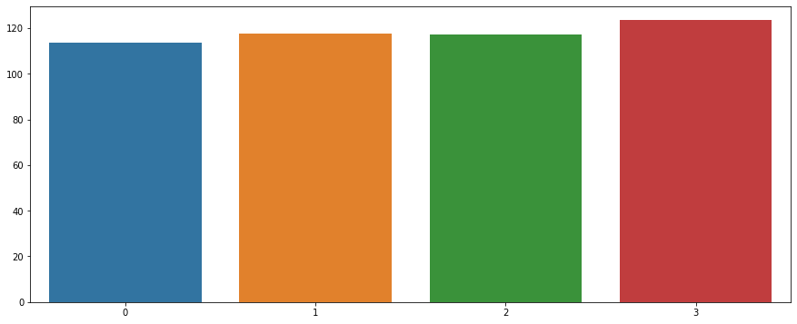

```python
plt.figure(figsize=(15,6))
sns.barplot(x=[0,1,2,3],y=a.values)
```

### Number of purchase by each segments

```python
a=temp1.groupby('segment')['n_purchase'].mean()
a
```

```
segment
0    22.756614
1    24.902913
2    34.602041
3    39.827273
Name: n_purchase, dtype: float64
```

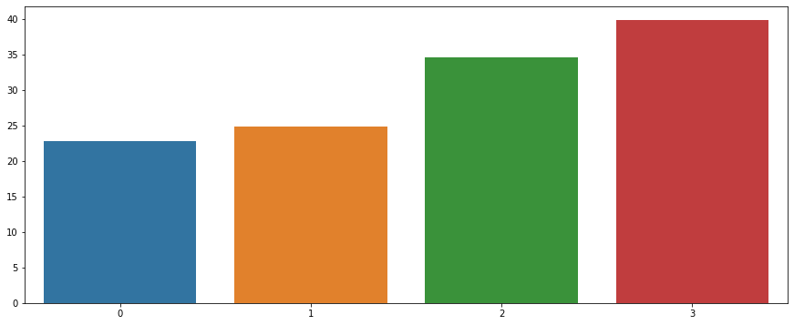

```python
plt.figure(figsize=(15,6))
sns.barplot(x=[0,1,2,3],y=a.values)
```

## Brand Choice

```python
# considering the brand choice who have made a single purchase
temp2=purchase_df[purchase_df['Incidence']==1]
temp2
```

|  | ID | Day | Incidence | Brand | Quantity | Last_Inc_Brand | Last_Inc_Quantity | Price_1 | Price_2 | Price_3 | ... | Promotion_4 | Promotion_5 | Sex | Marital status | Age | Education | Income | Occupation | Settlement size | segment |
| --- | --- | --- | --- | --- | --- | --- | --- | --- | --- | --- | --- | --- | --- | --- | --- | --- | --- | --- | --- | --- | --- |
| 6 | 200000001 | 28 | 1 | 2 | 2 | 0 | 0 | 1.50 | 1.90 | 1.99 | ... | 0 | 0 | 0 | 0 | 47 | 1 | 110866 | 1 | 0 | 0 |
| 11 | 200000001 | 58 | 1 | 5 | 1 | 0 | 0 | 1.39 | 1.90 | 1.91 | ... | 0 | 1 | 0 | 0 | 47 | 1 | 110866 | 1 | 0 | 0 |
| 19 | 200000001 | 110 | 1 | 1 | 2 | 0 | 0 | 1.47 | 1.90 | 1.99 | ... | 1 | 0 | 0 | 0 | 47 | 1 | 110866 | 1 | 0 | 0 |
| 24 | 200000001 | 142 | 1 | 4 | 1 | 0 | 0 | 1.21 | 1.35 | 1.99 | ... | 0 | 0 | 0 | 0 | 47 | 1 | 110866 | 1 | 0 | 0 |
| 29 | 200000001 | 183 | 1 | 2 | 3 | 0 | 0 | 1.46 | 1.88 | 1.97 | ... | 1 | 1 | 0 | 0 | 47 | 1 | 110866 | 1 | 0 | 0 |
| ... | ... | ... | ... | ... | ... | ... | ... | ... | ... | ... | ... | ... | ... | ... | ... | ... | ... | ... | ... | ... | ... |
| 58621 | 200000500 | 296 | 1 | 2 | 6 | 0 | 0 | 1.48 | 1.89 | 2.01 | ... | 0 | 0 | 0 | 0 | 42 | 1 | 120946 | 1 | 0 | 0 |
| 58648 | 200000500 | 460 | 1 | 1 | 12 | 0 | 0 | 1.35 | 1.57 | 2.02 | ... | 0 | 0 | 0 | 0 | 42 | 1 | 120946 | 1 | 0 | 0 |
| 58674 | 200000500 | 641 | 1 | 2 | 7 | 0 | 0 | 1.50 | 1.85 | 2.06 | ... | 0 | 0 | 0 | 0 | 42 | 1 | 120946 | 1 | 0 | 0 |
| 58687 | 200000500 | 697 | 1 | 2 | 6 | 0 | 0 | 1.42 | 1.51 | 1.97 | ... | 0 | 0 | 0 | 0 | 42 | 1 | 120946 | 1 | 0 | 0 |
| 58691 | 200000500 | 722 | 1 | 2 | 3 | 0 | 0 | 1.51 | 1.82 | 2.09 | ... | 0 | 0 | 0 | 0 | 42 | 1 | 120946 | 1 | 0 | 0 |

14638 rows × 25 columns

```python
temp3=temp2[['Brand','segment']]
temp3
```

|  | Brand | segment |
| --- | --- | --- |
| 6 | 2 | 0 |
| 11 | 5 | 0 |
| 19 | 1 | 0 |
| 24 | 4 | 0 |
| 29 | 2 | 0 |
| ... | ... | ... |
| 58621 | 2 | 0 |
| 58648 | 1 | 0 |
| 58674 | 2 | 0 |
| 58687 | 2 | 0 |
| 58691 | 2 | 0 |

14638 rows × 2 columns

```python
#Choice of barnd for each segments
temp3.groupby('Brand')['segment'].value_counts()
```

```
Brand  segment
1      1           527
       0           508
       3           173
       2           142
2      0          2958
       1           908
       3           407
       2           269
3      1           521
       0           117
       3           115
       2            88
4      2          2189
       3           347
       0           264
       1           127
5      3          3339
       2           703
       1           482
       0           454
Name: segment, dtype: int64
```

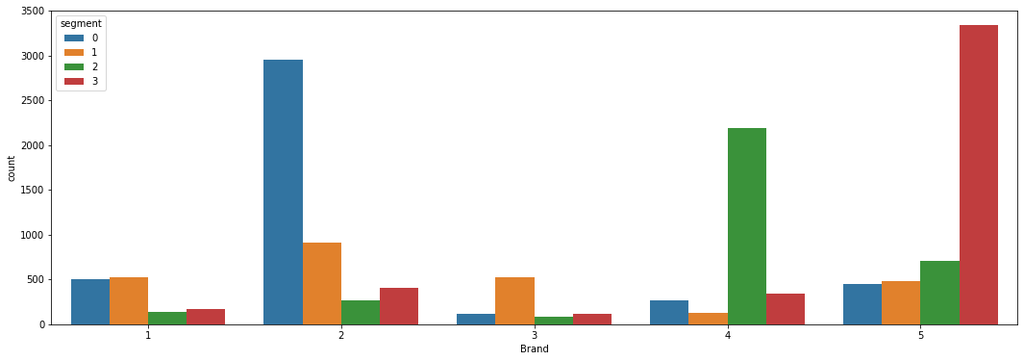

```python
plt.figure(figsize=(18,6))
sns.countplot(x='Brand',data=temp3,hue='segment')
```

Segment 0 is more intested in brand 2  
Segment 2 is more intested in brand 4  
Segment 3 is more intested in brand 5

## Revenue and Price of each brand

### Avg Price of each brand

```python
p1=purchase_df['Price_1'].mean()
p1
```

```
1.3920743529893755
```

```python
p2=purchase_df['Price_2'].mean()
p2
```

```
1.780998926618093
```

```python
p3=purchase_df['Price_3'].mean()
p3
```

```
2.0067887141571523
```

```python
p4=purchase_df['Price_4'].mean()
p4
```

```
2.159945308640629
```

```python
p5=purchase_df['Price_5'].mean()
p5
```

```
2.654797676043362
```

```python
temp4=pd.DataFrame(data=[p1,p2,p3,p4,p5],columns=["mean_price"])
temp4
```

|  | mean_price |
| --- | --- |
| 0 | 1.392074 |
| 1 | 1.780999 |
| 2 | 2.006789 |
| 3 | 2.159945 |
| 4 | 2.654798 |

```python
brand=['Brand_1','Brand_2','Brand_3','Brand_4','Brand_5']
brand
```

```
['Brand_1', 'Brand_2', 'Brand_3', 'Brand_4', 'Brand_5']
```

```python
temp4['brand']=brand
```

```python
temp4.head()
```

|  | mean_price | brand |
| --- | --- | --- |
| 0 | 1.392074 | Brand_1 |
| 1 | 1.780999 | Brand_2 |
| 2 | 2.006789 | Brand_3 |
| 3 | 2.159945 | Brand_4 |
| 4 | 2.654798 | Brand_5 |

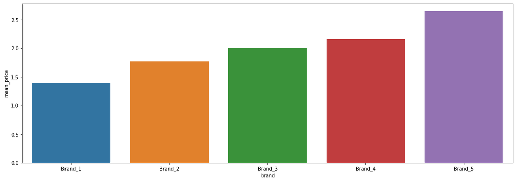

```python
plt.figure(figsize=(18,6))
sns.barplot(x='brand',y='mean_price',data=temp4)
```

Brand 5 seems to to most costly than other bands

### Revenue of each brand

Revenue can be defined as (price of each product) * (total quantity of product purchased)

#### For Brand 1

```python
x=purchase_df[purchase_df['Brand']==1]
y=x[['Price_1','Quantity','segment']]
y['Revenue_1']=y['Price_1']*y['Quantity']
y
```

|  | Price_1 | Quantity | segment | Revenue_1 |
| --- | --- | --- | --- | --- |
| 19 | 1.47 | 2 | 0 | 2.94 |
| 556 | 1.31 | 5 | 3 | 6.55 |
| 604 | 1.35 | 1 | 3 | 1.35 |
| 799 | 1.21 | 2 | 0 | 2.42 |
| 858 | 1.39 | 3 | 0 | 4.17 |
| ... | ... | ... | ... | ... |
| 58400 | 1.10 | 3 | 1 | 3.30 |
| 58526 | 1.33 | 3 | 0 | 3.99 |
| 58527 | 1.34 | 3 | 0 | 4.02 |
| 58617 | 1.37 | 6 | 0 | 8.22 |
| 58648 | 1.35 | 12 | 0 | 16.20 |

1350 rows × 4 columns

```python
r1=y.groupby('segment')['Revenue_1'].sum()
r1
```

```
segment
0    2258.90
1    2611.19
2     699.47
3     736.09
Name: Revenue_1, dtype: float64
```

```python
revenue_df=pd.DataFrame(r1)
revenue_df.head()
```

| segment | Revenue_1 |
| --- | --- |
| 0 | 2258.90 |
| 1 | 2611.19 |
| 2 | 699.47 |
| 3 | 736.09 |

#### For Brand 2

```python
x=purchase_df[purchase_df['Brand']==2]
y=x[['Price_2','Quantity','segment']]
y['Revenue_2']=y['Price_2']*y['Quantity']
y
```

|  | Price_2 | Quantity | segment | Revenue_2 |
| --- | --- | --- | --- | --- |
| 6 | 1.90 | 2 | 0 | 3.80 |
| 29 | 1.88 | 3 | 0 | 5.64 |
| 79 | 1.89 | 2 | 0 | 3.78 |
| 80 | 1.51 | 3 | 0 | 4.53 |
| 163 | 1.57 | 3 | 2 | 4.71 |
| ... | ... | ... | ... | ... |
| 58615 | 1.26 | 4 | 0 | 5.04 |
| 58621 | 1.89 | 6 | 0 | 11.34 |
| 58674 | 1.85 | 7 | 0 | 12.95 |
| 58687 | 1.51 | 6 | 0 | 9.06 |
| 58691 | 1.82 | 3 | 0 | 5.46 |

4542 rows × 4 columns

```python
r2=y.groupby('segment')['Revenue_2'].sum()
r2
```

```
segment
0    13955.14
1     4768.52
2     1298.23
3     1746.42
Name: Revenue_2, dtype: float64
```

```python
revenue_df=revenue_df.join(r2,on='segment')
revenue_df.head()
```

| segment | Revenue_1 | Revenue_2 |
| --- | --- | --- |
| 0 | 2258.90 | 13955.14 |
| 1 | 2611.19 | 4768.52 |
| 2 | 699.47 | 1298.23 |
| 3 | 736.09 | 1746.42 |

#### For Brand 3

```python
x=purchase_df[purchase_df['Brand']==3]
y=x[['Price_3','Quantity','segment']]
y['Revenue_3']=y['Price_3']*y['Quantity']
y
```

|  | Price_3 | Quantity | segment | Revenue_3 |
| --- | --- | --- | --- | --- |
| 591 | 1.99 | 1 | 3 | 1.99 |
| 631 | 2.01 | 2 | 3 | 4.02 |
| 632 | 2.06 | 2 | 3 | 4.12 |
| 1220 | 2.02 | 2 | 0 | 4.04 |
| 2193 | 1.99 | 1 | 3 | 1.99 |
| ... | ... | ... | ... | ... |
| 58431 | 2.07 | 3 | 1 | 6.21 |
| 58434 | 2.07 | 3 | 1 | 6.21 |
| 58435 | 2.01 | 4 | 1 | 8.04 |
| 58436 | 2.01 | 5 | 1 | 10.05 |
| 58444 | 2.06 | 3 | 1 | 6.18 |

841 rows × 4 columns

```python
r3=y.groupby('segment')['Revenue_3'].sum()
r3
```

```
segment
0     716.25
1    3909.17
2     731.35
3     664.75
Name: Revenue_3, dtype: float64
```

```python
revenue_df=revenue_df.join(r3,on='segment')
revenue_df.head()
```

| segment | Revenue_1 | Revenue_2 | Revenue_3 |
| --- | --- | --- | --- |
| 0 | 2258.90 | 13955.14 | 716.25 |
| 1 | 2611.19 | 4768.52 | 3909.17 |
| 2 | 699.47 | 1298.23 | 731.35 |
| 3 | 736.09 | 1746.42 | 664.75 |

#### For Brand 4

```python
x=purchase_df[purchase_df['Brand']==4]
y=x[['Price_4','Quantity','segment']]
y['Revenue_4']=y['Price_4']*y['Quantity']
y
```

|  | Price_4 | Quantity | segment | Revenue_4 |
| --- | --- | --- | --- | --- |
| 24 | 2.16 | 1 | 0 | 2.16 |
| 52 | 1.90 | 3 | 0 | 5.70 |
| 101 | 2.09 | 1 | 2 | 2.09 |
| 115 | 2.12 | 2 | 2 | 4.24 |
| 138 | 2.14 | 3 | 2 | 6.42 |
| ... | ... | ... | ... | ... |
| 58320 | 2.24 | 3 | 0 | 6.72 |
| 58322 | 2.24 | 5 | 0 | 11.20 |
| 58323 | 2.24 | 3 | 0 | 6.72 |
| 58327 | 2.24 | 5 | 0 | 11.20 |
| 58560 | 2.24 | 3 | 0 | 6.72 |

2927 rows × 4 columns

```python
r4=y.groupby('segment')['Revenue_4'].sum()
r4
```

```
segment
0     1629.31
1      861.38
2    14185.57
3     2363.84
Name: Revenue_4, dtype: float64
```

```python
revenue_df=revenue_df.join(r4,on='segment')
revenue_df.head()
```

| segment | Revenue_1 | Revenue_2 | Revenue_3 | Revenue_4 |
| --- | --- | --- | --- | --- |
| 0 | 2258.90 | 13955.14 | 716.25 | 1629.31 |
| 1 | 2611.19 | 4768.52 | 3909.17 | 861.38 |
| 2 | 699.47 | 1298.23 | 731.35 | 14185.57 |
| 3 | 736.09 | 1746.42 | 664.75 | 2363.84 |

#### For Brand 5

```python
x=purchase_df[purchase_df['Brand']==5]
y=x[['Price_5','Quantity','segment']]
y['Revenue_5']=y['Price_5']*y['Quantity']
y
```

|  | Price_5 | Quantity | segment | Revenue_5 |
| --- | --- | --- | --- | --- |
| 11 | 2.62 | 1 | 0 | 2.62 |
| 97 | 2.79 | 1 | 0 | 2.79 |
| 209 | 2.49 | 1 | 0 | 2.49 |
| 212 | 2.44 | 1 | 0 | 2.44 |
| 291 | 2.62 | 1 | 0 | 2.62 |
| ... | ... | ... | ... | ... |
| 58289 | 2.70 | 1 | 0 | 2.70 |
| 58471 | 2.62 | 1 | 0 | 2.62 |
| 58489 | 2.63 | 1 | 0 | 2.63 |
| 58506 | 2.64 | 2 | 0 | 5.28 |
| 58508 | 2.67 | 2 | 0 | 5.34 |

4978 rows × 4 columns

```python
r5=y.groupby('segment')['Revenue_5'].sum()
r5
```

```
segment
0     2230.50
1     2439.75
2     5509.69
3    19441.06
Name: Revenue_5, dtype: float64
```

```python
revenue_df=revenue_df.join(r5,on='segment')
revenue_df.head()
```

| segment | Revenue_1 | Revenue_2 | Revenue_3 | Revenue_4 | Revenue_5 |
| --- | --- | --- | --- | --- | --- |
| 0 | 2258.90 | 13955.14 | 716.25 | 1629.31 | 2230.50 |
| 1 | 2611.19 | 4768.52 | 3909.17 | 861.38 | 2439.75 |
| 2 | 699.47 | 1298.23 | 731.35 | 14185.57 | 5509.69 |
| 3 | 736.09 | 1746.42 | 664.75 | 2363.84 | 19441.06 |

```python
revenue_df['total_revenue']=revenue_df['Revenue_1']+revenue_df['Revenue_2']+revenue_df['Revenue_3']+revenue_df['Revenue_4']+revenue_df['Revenue_5']
```

### Revenue of each brand from different segments

```python
revenue_df.head()
```

| segment | Revenue_1 | Revenue_2 | Revenue_3 | Revenue_4 | Revenue_5 | total_revenue |
| --- | --- | --- | --- | --- | --- | --- |
| 0 | 2258.90 | 13955.14 | 716.25 | 1629.31 | 2230.50 | 20790.10 |
| 1 | 2611.19 | 4768.52 | 3909.17 | 861.38 | 2439.75 | 14590.01 |
| 2 | 699.47 | 1298.23 | 731.35 | 14185.57 | 5509.69 | 22424.31 |
| 3 | 736.09 | 1746.42 | 664.75 | 2363.84 | 19441.06 | 24952.16 |

# Predictive Analysis

## Price Elasticity Of Purchase Probability

### ->Price elasticity measures how a variable of interest changes when the price changes.

## Price elasticity of Purchase Probability

[figure not shown]

## Effect of elasticity

[figure not shown]

```python
purchase_df.head()
```

|  | ID | Day | Incidence | Brand | Quantity | Last_Inc_Brand | Last_Inc_Quantity | Price_1 | Price_2 | Price_3 | ... | Promotion_4 | Promotion_5 | Sex | Marital status | Age | Education | Income | Occupation | Settlement size | segment |
| --- | --- | --- | --- | --- | --- | --- | --- | --- | --- | --- | --- | --- | --- | --- | --- | --- | --- | --- | --- | --- | --- |
| 0 | 200000001 | 1 | 0 | 0 | 0 | 0 | 0 | 1.59 | 1.87 | 2.01 | ... | 0 | 0 | 0 | 0 | 47 | 1 | 110866 | 1 | 0 | 0 |
| 1 | 200000001 | 11 | 0 | 0 | 0 | 0 | 0 | 1.51 | 1.89 | 1.99 | ... | 0 | 0 | 0 | 0 | 47 | 1 | 110866 | 1 | 0 | 0 |
| 2 | 200000001 | 12 | 0 | 0 | 0 | 0 | 0 | 1.51 | 1.89 | 1.99 | ... | 0 | 0 | 0 | 0 | 47 | 1 | 110866 | 1 | 0 | 0 |
| 3 | 200000001 | 16 | 0 | 0 | 0 | 0 | 0 | 1.52 | 1.89 | 1.98 | ... | 0 | 0 | 0 | 0 | 47 | 1 | 110866 | 1 | 0 | 0 |
| 4 | 200000001 | 18 | 0 | 0 | 0 | 0 | 0 | 1.52 | 1.89 | 1.99 | ... | 0 | 0 | 0 | 0 | 47 | 1 | 110866 | 1 | 0 | 0 |

5 rows × 25 columns

### Bulding Logistic Regression Model for Purchase Probability

```python
purchase_df['Mean_price']=(purchase_df['Price_1']+purchase_df['Price_2']+purchase_df['Price_3']+purchase_df['Price_4']+purchase_df['Price_5'])/5
```

```python
x=purchase_df['Mean_price']
x=pd.DataFrame(x)
x
```

|  | Mean_price |
| --- | --- |
| 0 | 2.044 |
| 1 | 2.028 |
| 2 | 2.028 |
| 3 | 2.028 |
| 4 | 2.030 |
| ... | ... |
| 58688 | 2.060 |
| 58689 | 2.060 |
| 58690 | 2.086 |
| 58691 | 2.092 |
| 58692 | 2.092 |

58693 rows × 1 columns

```python
y=purchase_df['Incidence']
y
```

```
0        0
1        0
2        0
3        0
4        0
        ..
58688    0
58689    0
58690    0
58691    1
58692    0
Name: Incidence, Length: 58693, dtype: int64
```

```python
pr_model=LogisticRegression()
```

```python
pr_model.fit(x,y)
```

```
LogisticRegression(C=1.0, class_weight=None, dual=False, fit_intercept=True,
                   intercept_scaling=1, l1_ratio=None, max_iter=100,
                   multi_class='auto', n_jobs=None, penalty='l2',
                   random_state=None, solver='lbfgs', tol=0.0001, verbose=0,
                   warm_start=False)
```

```python
pr_model.coef_
```

```
array([[-2.3480548]])
```

### Calculating Purchase Probability

```python
a=purchase_df[['Price_1','Price_2','Price_3','Price_4','Price_5','Mean_price']]
a.describe()
```

|  | Price_1 | Price_2 | Price_3 | Price_4 | Price_5 | Mean_price |
| --- | --- | --- | --- | --- | --- | --- |
| count | 58693.000000 | 58693.000000 | 58693.000000 | 58693.000000 | 58693.000000 | 58693.000000 |
| mean | 1.392074 | 1.780999 | 2.006789 | 2.159945 | 2.654798 | 1.998921 |
| std | 0.091139 | 0.170868 | 0.046867 | 0.089825 | 0.098272 | 0.051744 |
| min | 1.100000 | 1.260000 | 1.870000 | 1.760000 | 2.110000 | 1.872000 |
| 25% | 1.340000 | 1.580000 | 1.970000 | 2.120000 | 2.630000 | 1.970000 |
| 50% | 1.390000 | 1.880000 | 2.010000 | 2.170000 | 2.670000 | 2.004000 |
| 75% | 1.470000 | 1.890000 | 2.060000 | 2.240000 | 2.700000 | 2.034000 |
| max | 1.590000 | 1.900000 | 2.140000 | 2.260000 | 2.800000 | 2.102000 |

We can see that the values ragnges between 1.1 to 2.8

```python
price_range=np.arange(0.5,3.5,0.01)
price_range
```

```
array([0.5 , 0.51, 0.52, 0.53, 0.54, 0.55, 0.56, 0.57, 0.58, 0.59, 0.6 ,
       0.61, 0.62, 0.63, 0.64, 0.65, 0.66, 0.67, 0.68, 0.69, 0.7 , 0.71,
       0.72, 0.73, 0.74, 0.75, 0.76, 0.77, 0.78, 0.79, 0.8 , 0.81, 0.82,
       0.83, 0.84, 0.85, 0.86, 0.87, 0.88, 0.89, 0.9 , 0.91, 0.92, 0.93,
       0.94, 0.95, 0.96, 0.97, 0.98, 0.99, 1.  , 1.01, 1.02, 1.03, 1.04,
       1.05, 1.06, 1.07, 1.08, 1.09, 1.1 , 1.11, 1.12, 1.13, 1.14, 1.15,
       1.16, 1.17, 1.18, 1.19, 1.2 , 1.21, 1.22, 1.23, 1.24, 1.25, 1.26,
       1.27, 1.28, 1.29, 1.3 , 1.31, 1.32, 1.33, 1.34, 1.35, 1.36, 1.37,
       1.38, 1.39, 1.4 , 1.41, 1.42, 1.43, 1.44, 1.45, 1.46, 1.47, 1.48,
       1.49, 1.5 , 1.51, 1.52, 1.53, 1.54, 1.55, 1.56, 1.57, 1.58, 1.59,
       1.6 , 1.61, 1.62, 1.63, 1.64, 1.65, 1.66, 1.67, 1.68, 1.69, 1.7 ,
       1.71, 1.72, 1.73, 1.74, 1.75, 1.76, 1.77, 1.78, 1.79, 1.8 , 1.81,
       1.82, 1.83, 1.84, 1.85, 1.86, 1.87, 1.88, 1.89, 1.9 , 1.91, 1.92,
       1.93, 1.94, 1.95, 1.96, 1.97, 1.98, 1.99, 2.  , 2.01, 2.02, 2.03,
       2.04, 2.05, 2.06, 2.07, 2.08, 2.09, 2.1 , 2.11, 2.12, 2.13, 2.14,
       2.15, 2.16, 2.17, 2.18, 2.19, 2.2 , 2.21, 2.22, 2.23, 2.24, 2.25,
       2.26, 2.27, 2.28, 2.29, 2.3 , 2.31, 2.32, 2.33, 2.34, 2.35, 2.36,
       2.37, 2.38, 2.39, 2.4 , 2.41, 2.42, 2.43, 2.44, 2.45, 2.46, 2.47,
       2.48, 2.49, 2.5 , 2.51, 2.52, 2.53, 2.54, 2.55, 2.56, 2.57, 2.58,
       2.59, 2.6 , 2.61, 2.62, 2.63, 2.64, 2.65, 2.66, 2.67, 2.68, 2.69,
       2.7 , 2.71, 2.72, 2.73, 2.74, 2.75, 2.76, 2.77, 2.78, 2.79, 2.8 ,
       2.81, 2.82, 2.83, 2.84, 2.85, 2.86, 2.87, 2.88, 2.89, 2.9 , 2.91,
       2.92, 2.93, 2.94, 2.95, 2.96, 2.97, 2.98, 2.99, 3.  , 3.01, 3.02,
       3.03, 3.04, 3.05, 3.06, 3.07, 3.08, 3.09, 3.1 , 3.11, 3.12, 3.13,
       3.14, 3.15, 3.16, 3.17, 3.18, 3.19, 3.2 , 3.21, 3.22, 3.23, 3.24,
       3.25, 3.26, 3.27, 3.28, 3.29, 3.3 , 3.31, 3.32, 3.33, 3.34, 3.35,
       3.36, 3.37, 3.38, 3.39, 3.4 , 3.41, 3.42, 3.43, 3.44, 3.45, 3.46,
       3.47, 3.48, 3.49])
```

```python
price_range_df = pd.DataFrame(price_range)
```

```python
price_range_df
```

|  | 0 |
| --- | --- |
| 0 | 0.50 |
| 1 | 0.51 |
| 2 | 0.52 |
| 3 | 0.53 |
| 4 | 0.54 |
| ... | ... |
| 295 | 3.45 |
| 296 | 3.46 |
| 297 | 3.47 |
| 298 | 3.48 |
| 299 | 3.49 |

300 rows × 1 columns

```python
prediction=pr_model.predict_proba(price_range_df)
#It gives two value the probability of no purchase and probability of purchase
```

```python
purchase_probability=prediction[:,1]
purchase_probability
```

```
array([0.91789303, 0.91610596, 0.91428362, 0.91242548, 0.910531  ,
       0.90859965, 0.90663088, 0.90462415, 0.90257893, 0.90049467,
       0.89837085, 0.89620692, 0.89400234, 0.8917566 , 0.88946917,
       0.88713951, 0.88476711, 0.88235145, 0.87989203, 0.87738834,
       0.87483988, 0.87224617, 0.86960672, 0.86692105, 0.86418871,
       0.86140924, 0.85858219, 0.85570714, 0.85278366, 0.84981134,
       0.84678979, 0.84371863, 0.84059749, 0.83742604, 0.83420393,
       0.83093086, 0.82760652, 0.82423064, 0.82080297, 0.81732327,
       0.81379133, 0.81020696, 0.80657   , 0.80288029, 0.79913773,
       0.79534223, 0.79149372, 0.78759217, 0.78363757, 0.77962994,
       0.77556934, 0.77145585, 0.76728959, 0.76307071, 0.75879938,
       0.75447583, 0.7501003 , 0.74567308, 0.74119449, 0.73666488,
       0.73208466, 0.72745424, 0.7227741 , 0.71804474, 0.71326671,
       0.70844058, 0.70356699, 0.69864658, 0.69368006, 0.68866816,
       0.68361166, 0.67851138, 0.67336816, 0.66818289, 0.66295652,
       0.65768999, 0.65238432, 0.64704055, 0.64165976, 0.63624305,
       0.63079157, 0.62530651, 0.61978908, 0.61424052, 0.60866212,
       0.60305518, 0.59742104, 0.59176106, 0.58607665, 0.58036921,
       0.57464019, 0.56889106, 0.56312329, 0.55733841, 0.55153792,
       0.54572339, 0.53989635, 0.53405839, 0.52821108, 0.52235602,
       0.51649481, 0.51062906, 0.50476038, 0.49889039, 0.4930207 ,
       0.48715294, 0.48128872, 0.47542965, 0.46957733, 0.46373337,
       0.45789935, 0.45207685, 0.44626745, 0.44047268, 0.43469409,
       0.42893319, 0.42319149, 0.41747046, 0.41177155, 0.40609621,
       0.40044584, 0.39482183, 0.38922552, 0.38365825, 0.37812131,
       0.37261597, 0.36714347, 0.361705  , 0.35630173, 0.35093481,
       0.34560531, 0.34031433, 0.33506286, 0.32985192, 0.32468244,
       0.31955535, 0.31447152, 0.30943179, 0.30443696, 0.29948778,
       0.29458499, 0.28972927, 0.28492126, 0.28016156, 0.27545074,
       0.27078934, 0.26617785, 0.26161671, 0.25710634, 0.25264713,
       0.24823942, 0.24388351, 0.23957968, 0.23532815, 0.23112914,
       0.22698282, 0.22288931, 0.21884873, 0.21486115, 0.2109266 ,
       0.2070451 , 0.20321664, 0.19944116, 0.19571859, 0.19204884,
       0.18843178, 0.18486725, 0.18135509, 0.17789508, 0.17448702,
       0.17113066, 0.16782574, 0.16457196, 0.16136904, 0.15821665,
       0.15511445, 0.15206209, 0.1490592 , 0.14610539, 0.14320027,
       0.14034341, 0.1375344 , 0.1347728 , 0.13205816, 0.12939002,
       0.12676792, 0.12419137, 0.12165989, 0.119173  , 0.11673018,
       0.11433094, 0.11197476, 0.10966112, 0.10738951, 0.1051594 ,
       0.10297025, 0.10082155, 0.09871274, 0.09664331, 0.0946127 ,
       0.09262039, 0.09066583, 0.08874848, 0.0868678 , 0.08502326,
       0.08321431, 0.08144043, 0.07970108, 0.07799571, 0.07632382,
       0.07468485, 0.0730783 , 0.07150363, 0.06996034, 0.0684479 ,
       0.0669658 , 0.06551354, 0.0640906 , 0.0626965 , 0.06133074,
       0.05999282, 0.05868227, 0.0573986 , 0.05614133, 0.05491   ,
       0.05370413, 0.05252328, 0.05136698, 0.05023479, 0.04912626,
       0.04804096, 0.04697845, 0.0459383 , 0.0449201 , 0.04392342,
       0.04294787, 0.04199303, 0.04105851, 0.04014392, 0.03924886,
       0.03837296, 0.03751585, 0.03667715, 0.0358565 , 0.03505355,
       0.03426794, 0.03349932, 0.03274736, 0.03201172, 0.03129207,
       0.03058809, 0.02989945, 0.02922585, 0.02856698, 0.02792254,
       0.02729223, 0.02667575, 0.02607283, 0.02548317, 0.02490651,
       0.02434258, 0.0237911 , 0.02325182, 0.02272447, 0.02220882,
       0.0217046 , 0.02121159, 0.02072954, 0.02025821, 0.01979739,
       0.01934684, 0.01890634, 0.01847569, 0.01805466, 0.01764306,
       0.01724068, 0.01684731, 0.01646277, 0.01608687, 0.01571941,
       0.01536021, 0.0150091 , 0.01466589, 0.01433041, 0.0140025 ,
       0.01368199, 0.01336872, 0.01306252, 0.01276325, 0.01247075,
       0.01218487, 0.01190546, 0.01163238, 0.0113655 , 0.01110467,
       0.01084976, 0.01060063, 0.01035717, 0.01011925, 0.00988673])
```

```python
price_range_df['Purchase_probability']=purchase_probability
```

```python
price_range_df=price_range_df.rename(columns={0:"Price"})
price_range_df.head()
```

|  | Price | Purchase_probability |
| --- | --- | --- |
| 0 | 0.50 | 0.917893 |
| 1 | 0.51 | 0.916106 |
| 2 | 0.52 | 0.914284 |
| 3 | 0.53 | 0.912425 |
| 4 | 0.54 | 0.910531 |

### Calculating Price Elasticity

```python
coef=pr_model.coef_[0][0]
coef
```

```
-2.348054804838444
```

```python
pe=coef*price_range_df['Price']*(1-price_range_df['Purchase_probability'])
pe
```

```
0     -0.096396
1     -0.100464
2     -0.104659
3     -0.108984
4     -0.113442
         ...
295   -8.012897
296   -8.038147
297   -8.063363
298   -8.088544
299   -8.113692
Length: 300, dtype: float64
```

```python
price_range_df['Price_elasticity']=pe
```

```python
price_range_df.head()
```

|  | Price | Purchase_probability | Price_elasticity |
| --- | --- | --- | --- |
| 0 | 0.50 | 0.917893 | -0.096396 |
| 1 | 0.51 | 0.916106 | -0.100464 |
| 2 | 0.52 | 0.914284 | -0.104659 |
| 3 | 0.53 | 0.912425 | -0.108984 |
| 4 | 0.54 | 0.910531 | -0.113442 |

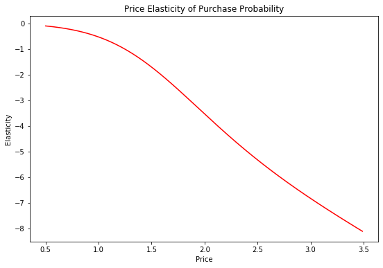

```python
plt.figure(figsize = (9, 6))
plt.plot(price_range_df['Price'],price_range_df['Price_elasticity'] ,color='red')
plt.xlabel('Price')
plt.ylabel('Elasticity')
plt.title('Price Elasticity of Purchase Probability')
```

## Calculating Purchase Probability and Price Elasticity for each segments

## For segment 0

```python
seg_0_df=purchase_df[purchase_df['segment']==0]
mean_price=(seg_0_df['Price_1']+seg_0_df['Price_2']+seg_0_df['Price_3']+seg_0_df['Price_4']+seg_0_df['Price_5'])/5
x=pd.DataFrame(mean_price)
y=seg_0_df['Incidence']
pr_model_0=LogisticRegression()
pr_model_0.fit(x,y)
coef=pr_model_0.coef_[0][0]
p=price_range_df.iloc[:,0]
p=pd.DataFrame(p)
prediction=pr_model_0.predict_proba(p)
price_range_df['Purchase_probability_0']=prediction[:,1]
```

```python
pe=coef*price_range_df['Price']*(1-price_range_df['Purchase_probability_0'])
pe
```

```
0      -0.030921
1      -0.032688
2      -0.034541
3      -0.036486
4      -0.038526
         ...
295   -12.541785
296   -12.578702
297   -12.615602
298   -12.652486
299   -12.689354
Length: 300, dtype: float64
```

```python
price_range_df['Price_elasticity_0']=pe
price_range_df.head()
```

|  | Price | Purchase_probability | Price_elasticity | Purchase_probability_0 | Price_elasticity_0 |
| --- | --- | --- | --- | --- | --- |
| 0 | 0.50 | 0.917893 | -0.096396 | 0.983010 | -0.030921 |
| 1 | 0.51 | 0.916106 | -0.100464 | 0.982391 | -0.032688 |
| 2 | 0.52 | 0.914284 | -0.104659 | 0.981750 | -0.034541 |
| 3 | 0.53 | 0.912425 | -0.108984 | 0.981087 | -0.036486 |
| 4 | 0.54 | 0.910531 | -0.113442 | 0.980399 | -0.038526 |

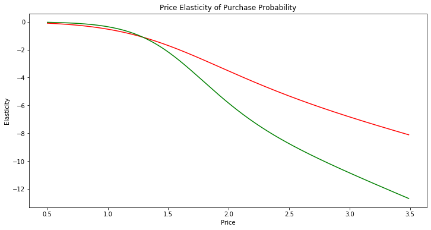

```python
plt.figure(figsize = (12, 6))
plt.plot(price_range_df['Price'],price_range_df['Price_elasticity'] ,color='red')
plt.plot(price_range_df['Price'],price_range_df['Price_elasticity_0'] ,color='green')
plt.xlabel('Price')
plt.ylabel('Elasticity')
plt.title('Price Elasticity of Purchase Probability')
```

## For segment 1

```python
seg_1_df=purchase_df[purchase_df['segment']==1]
mean_price=(seg_1_df['Price_1']+seg_1_df['Price_2']+seg_1_df['Price_3']+seg_1_df['Price_4']+seg_1_df['Price_5'])/5
x=pd.DataFrame(mean_price)
y=seg_1_df['Incidence']
pr_model_1=LogisticRegression()
pr_model_1.fit(x,y)
coef=pr_model_1.coef_[0][0]
p=price_range_df.iloc[:,0]
p=pd.DataFrame(p)
prediction=pr_model_1.predict_proba(p)
price_range_df['Purchase_probability_1']=prediction[:,1]
```

```python
pe=coef*price_range_df['Price']*(1-price_range_df['Purchase_probability_1'])
pe
```

```
0     -0.211169
1     -0.217739
2     -0.224417
3     -0.231204
4     -0.238099
         ...
295   -5.051673
296   -5.068529
297   -5.085366
298   -5.102185
299   -5.118986
Length: 300, dtype: float64
```

```python
price_range_df['Price_elasticity_1']=pe
price_range_df.head()
```

|  | Price | Purchase_probability | Price_elasticity | Purchase_probability_0 | Price_elasticity_0 | Purchase_probability_1 | Price_elasticity_1 |
| --- | --- | --- | --- | --- | --- | --- | --- |
| 0 | 0.50 | 0.917893 | -0.096396 | 0.983010 | -0.030921 | 0.719981 | -0.211169 |
| 1 | 0.51 | 0.916106 | -0.100464 | 0.982391 | -0.032688 | 0.716930 | -0.217739 |
| 2 | 0.52 | 0.914284 | -0.104659 | 0.981750 | -0.034541 | 0.713859 | -0.224417 |
| 3 | 0.53 | 0.912425 | -0.108984 | 0.981087 | -0.036486 | 0.710769 | -0.231204 |
| 4 | 0.54 | 0.910531 | -0.113442 | 0.980399 | -0.038526 | 0.707658 | -0.238099 |

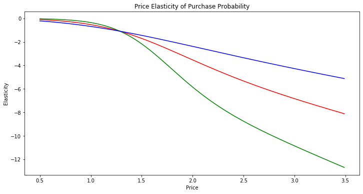

```python
plt.figure(figsize = (12, 6))
plt.plot(price_range_df['Price'],price_range_df['Price_elasticity'] ,color='red')
plt.plot(price_range_df['Price'],price_range_df['Price_elasticity_0'] ,color='green')
plt.plot(price_range_df['Price'],price_range_df['Price_elasticity_1'] ,color='blue')
plt.xlabel('Price')
plt.ylabel('Elasticity')
plt.title('Price Elasticity of Purchase Probability')
```

## For segment 2

```python
seg_2_df=purchase_df[purchase_df['segment']==2]
mean_price=(seg_2_df['Price_1']+seg_2_df['Price_2']+seg_2_df['Price_3']+seg_2_df['Price_4']+seg_2_df['Price_5'])/5
x=pd.DataFrame(mean_price)
y=seg_2_df['Incidence']
pr_model_2=LogisticRegression()
pr_model_2.fit(x,y)
coef=pr_model_2.coef_[0][0]
p=price_range_df.iloc[:,0]
p=pd.DataFrame(p)
prediction=pr_model_2.predict_proba(p)
price_range_df['Purchase_probability_2']=prediction[:,1]
```

```python
pe=coef*price_range_df['Price']*(1-price_range_df['Purchase_probability_2'])
pe
```

```
0     -0.168042
1     -0.172967
2     -0.177962
3     -0.183027
4     -0.188165
         ...
295   -4.022022
296   -4.036889
297   -4.051739
298   -4.066574
299   -4.081392
Length: 300, dtype: float64
```

```python
price_range_df['Price_elasticity_2']=pe
price_range_df.head()
```

|  | Price | Purchase_probability | Price_elasticity | Purchase_probability_0 | Price_elasticity_0 | Purchase_probability_1 | Price_elasticity_1 | Purchase_probability_2 | Price_elasticity_2 |
| --- | --- | --- | --- | --- | --- | --- | --- | --- | --- |
| 0 | 0.50 | 0.917893 | -0.096396 | 0.983010 | -0.030921 | 0.719981 | -0.211169 | 0.730224 | -0.168042 |
| 1 | 0.51 | 0.916106 | -0.100464 | 0.982391 | -0.032688 | 0.716930 | -0.217739 | 0.727763 | -0.172967 |
| 2 | 0.52 | 0.914284 | -0.104659 | 0.981750 | -0.034541 | 0.713859 | -0.224417 | 0.725288 | -0.177962 |
| 3 | 0.53 | 0.912425 | -0.108984 | 0.981087 | -0.036486 | 0.710769 | -0.231204 | 0.722798 | -0.183027 |
| 4 | 0.54 | 0.910531 | -0.113442 | 0.980399 | -0.038526 | 0.707658 | -0.238099 | 0.720295 | -0.188165 |

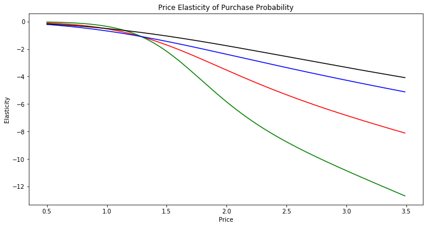

```python
plt.figure(figsize = (12, 6))
plt.plot(price_range_df['Price'],price_range_df['Price_elasticity'] ,color='red')
plt.plot(price_range_df['Price'],price_range_df['Price_elasticity_0'] ,color='green')
plt.plot(price_range_df['Price'],price_range_df['Price_elasticity_1'] ,color='blue')
plt.plot(price_range_df['Price'],price_range_df['Price_elasticity_2'] ,color='black')
plt.xlabel('Price')
plt.ylabel('Elasticity')
plt.title('Price Elasticity of Purchase Probability')
```

## For segment 3

```python
seg_3_df=purchase_df[purchase_df['segment']==3]
mean_price=(seg_3_df['Price_1']+seg_3_df['Price_2']+seg_3_df['Price_3']+seg_3_df['Price_4']+seg_3_df['Price_5'])/5
x=pd.DataFrame(mean_price)
y=seg_3_df['Incidence']
pr_model_3=LogisticRegression()
pr_model_3.fit(x,y)
coef=pr_model_3.coef_[0][0]
p=price_range_df.iloc[:,0]
p=pd.DataFrame(p)
prediction=pr_model_3.predict_proba(p)
price_range_df['Purchase_probability_3']=prediction[:,1]
```

```python
pe=coef*price_range_df['Price']*(1-price_range_df['Purchase_probability_3'])
pe
```

```
0     -0.119088
1     -0.123271
2     -0.127548
3     -0.131919
4     -0.136386
         ...
295   -5.680837
296   -5.700994
297   -5.721114
298   -5.741197
299   -5.761245
Length: 300, dtype: float64
```

```python
price_range_df['Price_elasticity_3']=pe
price_range_df.head()
```

|  | Price | Purchase_probability | Price_elasticity | Purchase_probability_0 | Price_elasticity_0 | Purchase_probability_1 | Price_elasticity_1 | Purchase_probability_2 | Price_elasticity_2 | Purchase_probability_3 | Price_elasticity_3 |
| --- | --- | --- | --- | --- | --- | --- | --- | --- | --- | --- | --- |
| 0 | 0.50 | 0.917893 | -0.096396 | 0.983010 | -0.030921 | 0.719981 | -0.211169 | 0.730224 | -0.168042 | 0.860871 | -0.119088 |
| 1 | 0.51 | 0.916106 | -0.100464 | 0.982391 | -0.032688 | 0.716930 | -0.217739 | 0.727763 | -0.172967 | 0.858808 | -0.123271 |
| 2 | 0.52 | 0.914284 | -0.104659 | 0.981750 | -0.034541 | 0.713859 | -0.224417 | 0.725288 | -0.177962 | 0.856719 | -0.127548 |
| 3 | 0.53 | 0.912425 | -0.108984 | 0.981087 | -0.036486 | 0.710769 | -0.231204 | 0.722798 | -0.183027 | 0.854605 | -0.131919 |
| 4 | 0.54 | 0.910531 | -0.113442 | 0.980399 | -0.038526 | 0.707658 | -0.238099 | 0.720295 | -0.188165 | 0.852465 | -0.136386 |

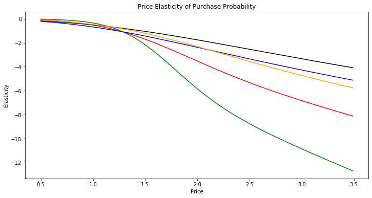

```python
plt.figure(figsize = (12, 6))
plt.plot(price_range_df['Price'],price_range_df['Price_elasticity'] ,color='red')
plt.plot(price_range_df['Price'],price_range_df['Price_elasticity_0'] ,color='green')
plt.plot(price_range_df['Price'],price_range_df['Price_elasticity_1'] ,color='blue')
plt.plot(price_range_df['Price'],price_range_df['Price_elasticity_2'] ,color='black')
plt.plot(price_range_df['Price'],price_range_df['Price_elasticity_3'] ,color='orange')
plt.xlabel('Price')
plt.ylabel('Elasticity')
plt.title('Price Elasticity of Purchase Probability')
```

## Purchase Probability with Promotion Feature

```python
Mean_promotion=(purchase_df['Promotion_1']+purchase_df['Promotion_2']+purchase_df['Promotion_3']+purchase_df['Promotion_4']+purchase_df['Promotion_5'])/5
```

```python
x=purchase_df['Mean_price']
x=pd.DataFrame(x)
x
```

|  | Mean_price |
| --- | --- |
| 0 | 2.044 |
| 1 | 2.028 |
| 2 | 2.028 |
| 3 | 2.028 |
| 4 | 2.030 |
| ... | ... |
| 58688 | 2.060 |
| 58689 | 2.060 |
| 58690 | 2.086 |
| 58691 | 2.092 |
| 58692 | 2.092 |

58693 rows × 1 columns

```python
x['promotion']=Mean_promotion
x
```

|  | Mean_price | promotion |
| --- | --- | --- |
| 0 | 2.044 | 0.2 |
| 1 | 2.028 | 0.0 |
| 2 | 2.028 | 0.0 |
| 3 | 2.028 | 0.0 |
| 4 | 2.030 | 0.0 |
| ... | ... | ... |
| 58688 | 2.060 | 0.2 |
| 58689 | 2.060 | 0.0 |
| 58690 | 2.086 | 0.0 |
| 58691 | 2.092 | 0.0 |
| 58692 | 2.092 | 0.0 |

58693 rows × 2 columns

```python
y=purchase_df['Incidence']
y
```

```
0        0
1        0
2        0
3        0
4        0
        ..
58688    0
58689    0
58690    0
58691    1
58692    0
Name: Incidence, Length: 58693, dtype: int64
```

```python
promo_model=LogisticRegression()
```

```python
promo_model.fit(x,y)
```

```
LogisticRegression(C=1.0, class_weight=None, dual=False, fit_intercept=True,
                   intercept_scaling=1, l1_ratio=None, max_iter=100,
                   multi_class='auto', n_jobs=None, penalty='l2',
                   random_state=None, solver='lbfgs', tol=0.0001, verbose=0,
                   warm_start=False)
```

```python
promo_model.coef_
```

```
array([[-1.49402641,  0.56152541]])
```

```python
coef=promo_model.coef_[0][0]
coef
```

```
-1.494026412813302
```

## Price Elasticity with Promotion

```python
promo_df=price_range_df['Price']
promo_df=pd.DataFrame(promo_df)
```

```python
promo_df['promotion']=1
```

```python
promo_df
```

|  | Price | promotion |
| --- | --- | --- |
| 0 | 0.50 | 1 |
| 1 | 0.51 | 1 |
| 2 | 0.52 | 1 |
| 3 | 0.53 | 1 |
| 4 | 0.54 | 1 |
| ... | ... | ... |
| 295 | 3.45 | 1 |
| 296 | 3.46 | 1 |
| 297 | 3.47 | 1 |
| 298 | 3.48 | 1 |
| 299 | 3.49 | 1 |

300 rows × 2 columns

```python
prediction=promo_model.predict_proba(promo_df)
```

```python
promo = prediction[:, 1]
pe=coef*promo_df['Price']*(1-promo)
pe
```

```
0     -0.125732
1     -0.129848
2     -0.134043
3     -0.138318
4     -0.142674
         ...
295   -4.861622
296   -4.879824
297   -4.897996
298   -4.916137
299   -4.934247
Name: Price, Length: 300, dtype: float64
```

```python
promo_df['promotion_elasticity']=pe
promo_df.head()
```

|  | Price | promotion | promotion_elasticity |
| --- | --- | --- | --- |
| 0 | 0.50 | 1 | -0.125732 |
| 1 | 0.51 | 1 | -0.129848 |
| 2 | 0.52 | 1 | -0.134043 |
| 3 | 0.53 | 1 | -0.138318 |
| 4 | 0.54 | 1 | -0.142674 |

## Price Elasticity without Promotion

```python
no_promo_df=price_range_df['Price']
no_promo_df=pd.DataFrame(no_promo_df)
```

```python
no_promo_df['promotion']=0
```

```python
no_promo_df
```

|  | Price | promotion |
| --- | --- | --- |
| 0 | 0.50 | 0 |
| 1 | 0.51 | 0 |
| 2 | 0.52 | 0 |
| 3 | 0.53 | 0 |
| 4 | 0.54 | 0 |
| ... | ... | ... |
| 295 | 3.45 | 0 |
| 296 | 3.46 | 0 |
| 297 | 3.47 | 0 |
| 298 | 3.48 | 0 |
| 299 | 3.49 | 0 |

300 rows × 2 columns

```python
prediction=promo_model.predict_proba(no_promo_df)
```

```python
no_promo = prediction[:, 1]
pe=coef*no_promo_df['Price']*(1-no_promo)
pe
```

```
0     -0.195644
1     -0.201765
2     -0.207989
3     -0.214316
4     -0.220747
         ...
295   -4.983237
296   -5.000143
297   -5.017029
298   -5.033896
299   -5.050743
Name: Price, Length: 300, dtype: float64
```

```python
no_promo_df['promotion_elasticity']=pe
promo_df.head()
```

|  | Price | promotion | promotion_elasticity |
| --- | --- | --- | --- |
| 0 | 0.50 | 1 | -0.125732 |
| 1 | 0.51 | 1 | -0.129848 |
| 2 | 0.52 | 1 | -0.134043 |
| 3 | 0.53 | 1 | -0.138318 |
| 4 | 0.54 | 1 | -0.142674 |

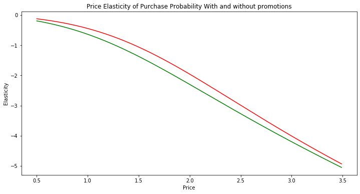

```python
plt.figure(figsize = (12, 6))
plt.plot(promo_df['Price'],promo_df['promotion_elasticity'] ,color='red')
plt.plot(no_promo_df['Price'],no_promo_df['promotion_elasticity'] ,color='green')
plt.xlabel('Price')
plt.ylabel('Elasticity')
plt.title('Price Elasticity of Purchase Probability With and without promotions')
```

According to model people are more likely to buy a product if there is some promotional activity rather than purchase a product with the same price, when it isn't on promotion.

# Price Elasticity With Brand Choice Probability

## Own-Price elasticity of Brand Choice

[figure not shown]

## Effect of elasticity of cross price brand

[figure not shown]

## Brand Choice

```python
brand=purchase_df[purchase_df['Incidence']==1]
brand
```

|  | ID | Day | Incidence | Brand | Quantity | Last_Inc_Brand | Last_Inc_Quantity | Price_1 | Price_2 | Price_3 | ... | Promotion_5 | Sex | Marital status | Age | Education | Income | Occupation | Settlement size | segment | Mean_price |
| --- | --- | --- | --- | --- | --- | --- | --- | --- | --- | --- | --- | --- | --- | --- | --- | --- | --- | --- | --- | --- | --- |
| 6 | 200000001 | 28 | 1 | 2 | 2 | 0 | 0 | 1.50 | 1.90 | 1.99 | ... | 0 | 0 | 0 | 47 | 1 | 110866 | 1 | 0 | 0 | 2.030 |
| 11 | 200000001 | 58 | 1 | 5 | 1 | 0 | 0 | 1.39 | 1.90 | 1.91 | ... | 1 | 0 | 0 | 47 | 1 | 110866 | 1 | 0 | 0 | 1.988 |
| 19 | 200000001 | 110 | 1 | 1 | 2 | 0 | 0 | 1.47 | 1.90 | 1.99 | ... | 0 | 0 | 0 | 47 | 1 | 110866 | 1 | 0 | 0 | 2.000 |
| 24 | 200000001 | 142 | 1 | 4 | 1 | 0 | 0 | 1.21 | 1.35 | 1.99 | ... | 0 | 0 | 0 | 47 | 1 | 110866 | 1 | 0 | 0 | 1.878 |
| 29 | 200000001 | 183 | 1 | 2 | 3 | 0 | 0 | 1.46 | 1.88 | 1.97 | ... | 1 | 0 | 0 | 47 | 1 | 110866 | 1 | 0 | 0 | 1.914 |
| ... | ... | ... | ... | ... | ... | ... | ... | ... | ... | ... | ... | ... | ... | ... | ... | ... | ... | ... | ... | ... | ... |
| 58621 | 200000500 | 296 | 1 | 2 | 6 | 0 | 0 | 1.48 | 1.89 | 2.01 | ... | 0 | 0 | 0 | 42 | 1 | 120946 | 1 | 0 | 0 | 2.050 |
| 58648 | 200000500 | 460 | 1 | 1 | 12 | 0 | 0 | 1.35 | 1.57 | 2.02 | ... | 0 | 0 | 0 | 42 | 1 | 120946 | 1 | 0 | 0 | 1.970 |
| 58674 | 200000500 | 641 | 1 | 2 | 7 | 0 | 0 | 1.50 | 1.85 | 2.06 | ... | 0 | 0 | 0 | 42 | 1 | 120946 | 1 | 0 | 0 | 2.088 |
| 58687 | 200000500 | 697 | 1 | 2 | 6 | 0 | 0 | 1.42 | 1.51 | 1.97 | ... | 0 | 0 | 0 | 42 | 1 | 120946 | 1 | 0 | 0 | 1.984 |
| 58691 | 200000500 | 722 | 1 | 2 | 3 | 0 | 0 | 1.51 | 1.82 | 2.09 | ... | 0 | 0 | 0 | 42 | 1 | 120946 | 1 | 0 | 0 | 2.092 |

14638 rows × 26 columns

```python
x=brand[['Price_1','Price_2','Price_3','Price_4','Price_5']]
x
```

|  | Price_1 | Price_2 | Price_3 | Price_4 | Price_5 |
| --- | --- | --- | --- | --- | --- |
| 6 | 1.50 | 1.90 | 1.99 | 2.09 | 2.67 |
| 11 | 1.39 | 1.90 | 1.91 | 2.12 | 2.62 |
| 19 | 1.47 | 1.90 | 1.99 | 1.97 | 2.67 |
| 24 | 1.21 | 1.35 | 1.99 | 2.16 | 2.68 |
| 29 | 1.46 | 1.88 | 1.97 | 1.89 | 2.37 |
| ... | ... | ... | ... | ... | ... |
| 58621 | 1.48 | 1.89 | 2.01 | 2.18 | 2.69 |
| 58648 | 1.35 | 1.57 | 2.02 | 2.21 | 2.70 |
| 58674 | 1.50 | 1.85 | 2.06 | 2.24 | 2.79 |
| 58687 | 1.42 | 1.51 | 1.97 | 2.24 | 2.78 |
| 58691 | 1.51 | 1.82 | 2.09 | 2.24 | 2.80 |

14638 rows × 5 columns

```python
y=brand['Brand']
y
```

```
6        2
11       5
19       1
24       4
29       2
        ..
58621    2
58648    1
58674    2
58687    2
58691    2
Name: Brand, Length: 14638, dtype: int64
```

### Building Multinomial Logistic Regression Model for all brands

```python
brand_model=LogisticRegression( solver="saga" ,multi_class = 'multinomial')
```

```python
brand_model.fit(x,y)
```

```
LogisticRegression(C=1.0, class_weight=None, dual=False, fit_intercept=True,
                   intercept_scaling=1, l1_ratio=None, max_iter=100,
                   multi_class='multinomial', n_jobs=None, penalty='l2',
                   random_state=None, solver='saga', tol=0.0001, verbose=0,
                   warm_start=False)
```

```python
brand_model.coef_
```

```
array([[-3.90972716,  0.66130754,  2.43938892,  0.7096652 , -0.19462282],
       [ 1.27932653, -1.87801624, -0.19536757, -0.20302646,  0.5929051 ],
       [ 1.60247295,  0.55261631,  0.42374419,  1.02346429,  0.42915718],
       [ 0.58053493,  0.39826924, -1.37896099, -1.24240053,  0.255707  ],
       [ 0.44739275,  0.26582316, -1.28880455, -0.2877025 , -1.08314646]])
```

```python
coef=pd.DataFrame(brand_model.coef_)
coef
```

|  | 0 | 1 | 2 | 3 | 4 |
| --- | --- | --- | --- | --- | --- |
| 0 | -3.909727 | 0.661308 | 2.439389 | 0.709665 | -0.194623 |
| 1 | 1.279327 | -1.878016 | -0.195368 | -0.203026 | 0.592905 |
| 2 | 1.602473 | 0.552616 | 0.423744 | 1.023464 | 0.429157 |
| 3 | 0.580535 | 0.398269 | -1.378961 | -1.242401 | 0.255707 |
| 4 | 0.447393 | 0.265823 | -1.288805 | -0.287703 | -1.083146 |

```python
coef=coef.rename(columns={0:"Price1",1:"Price2",2:"Price3",3:"Price4",4:"Price5"})
coef['Brand']=["Brand1","Brand2","Brand3","Brand4","Brand5"]
coef=coef.set_index('Brand')
coef
```

| Brand | Price1 | Price2 | Price3 | Price4 | Price5 |
| --- | --- | --- | --- | --- | --- |
| Brand1 | -3.909727 | 0.661308 | 2.439389 | 0.709665 | -0.194623 |
| Brand2 | 1.279327 | -1.878016 | -0.195368 | -0.203026 | 0.592905 |
| Brand3 | 1.602473 | 0.552616 | 0.423744 | 1.023464 | 0.429157 |
| Brand4 | 0.580535 | 0.398269 | -1.378961 | -1.242401 | 0.255707 |
| Brand5 | 0.447393 | 0.265823 | -1.288805 | -0.287703 | -1.083146 |

### As brand 5 is the most expensive brand we predict the elasticty for its own price

### Own Brand Price probability and elasticty of brand 5

### Own Brand 5 Probability

```python
price_range=np.arange(0.5,3.5,0.01)
```

```python
brand_5_prediction=pd.DataFrame(index=np.arange(price_range.size))
brand_5_prediction['Price_1']=brand['Price_1'].mean()
brand_5_prediction['Price_2']=brand['Price_2'].mean()
brand_5_prediction['Price_3']=brand['Price_3'].mean()
brand_5_prediction['Price_4']=brand['Price_4'].mean()
brand_5_prediction['Price_5']=price_range
brand_5_prediction
```

|  | Price_1 | Price_2 | Price_3 | Price_4 | Price_5 |
| --- | --- | --- | --- | --- | --- |
| 0 | 1.384559 | 1.764717 | 2.006694 | 2.159658 | 0.50 |
| 1 | 1.384559 | 1.764717 | 2.006694 | 2.159658 | 0.51 |
| 2 | 1.384559 | 1.764717 | 2.006694 | 2.159658 | 0.52 |
| 3 | 1.384559 | 1.764717 | 2.006694 | 2.159658 | 0.53 |
| 4 | 1.384559 | 1.764717 | 2.006694 | 2.159658 | 0.54 |
| ... | ... | ... | ... | ... | ... |
| 295 | 1.384559 | 1.764717 | 2.006694 | 2.159658 | 3.45 |
| 296 | 1.384559 | 1.764717 | 2.006694 | 2.159658 | 3.46 |
| 297 | 1.384559 | 1.764717 | 2.006694 | 2.159658 | 3.47 |
| 298 | 1.384559 | 1.764717 | 2.006694 | 2.159658 | 3.48 |
| 299 | 1.384559 | 1.764717 | 2.006694 | 2.159658 | 3.49 |

300 rows × 5 columns

```python
prediction=brand_model.predict_proba(brand_5_prediction)
prediction
```

```
array([[0.03270934, 0.02176178, 0.00579084, 0.02978322, 0.90995483],
       [0.03296338, 0.02210418, 0.00587233, 0.03015   , 0.90891011],
       [0.03321891, 0.02245165, 0.00595488, 0.03052086, 0.90785369],
       ...,
       [0.06903955, 0.47633997, 0.07793872, 0.23947368, 0.13720808],
       [0.06875621, 0.47813572, 0.07810454, 0.23956729, 0.13543623],
       [0.0684719 , 0.47992327, 0.07826828, 0.23965346, 0.13368309]])
```

```python
brand_predict_df=prediction[:,4]
brand_predict_df=pd.DataFrame(brand_predict_df)
brand_predict_df=brand_predict_df.rename(columns={0:"Own brand 5 probability"})
brand_predict_df
```

|  | Own brand 5 probability |
| --- | --- |
| 0 | 0.909955 |
| 1 | 0.908910 |
| 2 | 0.907854 |
| 3 | 0.906785 |
| 4 | 0.905705 |
| ... | ... |
| 295 | 0.140808 |
| 296 | 0.138999 |
| 297 | 0.137208 |
| 298 | 0.135436 |
| 299 | 0.133683 |

300 rows × 1 columns

### Own Brand 5 Elasticity

```python
beta5=coef.iloc[4,4]
beta5
```

```
-1.0831464633211267
```

```python
pe=beta5*brand_5_prediction['Price_5']*(1-brand_predict_df["Own brand 5 probability"])
brand_predict_df['own brand 5 elasticity']=pe
brand_predict_df
```

|  | Own brand 5 probability | own brand 5 elasticity |
| --- | --- | --- |
| 0 | 0.909955 | -0.048766 |
| 1 | 0.908910 | -0.050318 |
| 2 | 0.907854 | -0.051900 |
| 3 | 0.906785 | -0.053511 |
| 4 | 0.905705 | -0.055153 |
| ... | ... | ... |
| 295 | 0.140808 | -3.210675 |
| 296 | 0.138999 | -3.226763 |
| 297 | 0.137208 | -3.242819 |
| 298 | 0.135436 | -3.258843 |
| 299 | 0.133683 | -3.274835 |

300 rows × 2 columns

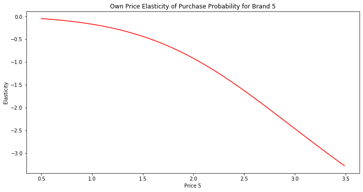

```python
plt.figure(figsize=(12,6))
plt.plot(brand_5_prediction['Price_5'],brand_predict_df['own brand 5 elasticity'],color='r')
plt.xlabel('Price 5')
plt.ylabel('Elasticity')
plt.title('Own Price Elasticity of Purchase Probability for Brand 5')
```

### Cross Price Elasticity and Probability Brand 5, Cross Brand 4

### Cross brand 5 probability

```python
cross_brand_5_prediction=pd.DataFrame(index=np.arange(price_range.size))
cross_brand_5_prediction['Price_1']=brand['Price_1'].mean()
cross_brand_5_prediction['Price_2']=brand['Price_2'].mean()
cross_brand_5_prediction['Price_3']=brand['Price_3'].mean()
cross_brand_5_prediction['Price_4']=price_range
cross_brand_5_prediction['Price_5']=brand['Price_5'].mean()
cross_brand_5_prediction
```

|  | Price_1 | Price_2 | Price_3 | Price_4 | Price_5 |
| --- | --- | --- | --- | --- | --- |
| 0 | 1.384559 | 1.764717 | 2.006694 | 0.50 | 2.654296 |
| 1 | 1.384559 | 1.764717 | 2.006694 | 0.51 | 2.654296 |
| 2 | 1.384559 | 1.764717 | 2.006694 | 0.52 | 2.654296 |
| 3 | 1.384559 | 1.764717 | 2.006694 | 0.53 | 2.654296 |
| 4 | 1.384559 | 1.764717 | 2.006694 | 0.54 | 2.654296 |
| ... | ... | ... | ... | ... | ... |
| 295 | 1.384559 | 1.764717 | 2.006694 | 3.45 | 2.654296 |
| 296 | 1.384559 | 1.764717 | 2.006694 | 3.46 | 2.654296 |
| 297 | 1.384559 | 1.764717 | 2.006694 | 3.47 | 2.654296 |
| 298 | 1.384559 | 1.764717 | 2.006694 | 3.48 | 2.654296 |
| 299 | 1.384559 | 1.764717 | 2.006694 | 3.49 | 2.654296 |

300 rows × 5 columns

```python
prediction=brand_model.predict_proba(cross_brand_5_prediction)
prediction
```

```
array([[0.00992943, 0.16391068, 0.00400333, 0.60892383, 0.21323274],
       [0.01008437, 0.16495588, 0.00407858, 0.60647036, 0.21441082],
       [0.01024144, 0.16600328, 0.00415513, 0.60401053, 0.21558961],
       ...,
       [0.2263484 , 0.24843964, 0.23175544, 0.04212454, 0.25133198],
       [0.22744865, 0.24737913, 0.2336139 , 0.04151102, 0.2500473 ],
       [0.22854504, 0.24631322, 0.23547778, 0.04090479, 0.24875917]])
```

```python
brand_predict_df['cross brand 5 probability(i.e 4)']=prediction[:,3]
brand_predict_df
```

|  | Own brand 5 probability | own brand 5 elasticity | cross brand 5 probability(i.e 4) |
| --- | --- | --- | --- |
| 0 | 0.909955 | -0.048766 | 0.608924 |
| 1 | 0.908910 | -0.050318 | 0.606470 |
| 2 | 0.907854 | -0.051900 | 0.604011 |
| 3 | 0.906785 | -0.053511 | 0.601544 |
| 4 | 0.905705 | -0.055153 | 0.599072 |
| ... | ... | ... | ... |
| 295 | 0.140808 | -3.210675 | 0.043374 |
| 296 | 0.138999 | -3.226763 | 0.042745 |
| 297 | 0.137208 | -3.242819 | 0.042125 |
| 298 | 0.135436 | -3.258843 | 0.041511 |
| 299 | 0.133683 | -3.274835 | 0.040905 |

300 rows × 3 columns

### Cross brand 5 elasticity

```python
beta5
```

```
-1.0831464633211267
```

```python
pe=-beta5*cross_brand_5_prediction['Price_4']*brand_predict_df["cross brand 5 probability(i.e 4)"]
brand_predict_df['cross brand 5 elasticity(i.e 4)']=pe
brand_predict_df
```

|  | Own brand 5 probability | own brand 5 elasticity | cross brand 5 probability(i.e 4) | cross brand 5 elasticity(i.e 4) |
| --- | --- | --- | --- | --- |
| 0 | 0.909955 | -0.048766 | 0.608924 | 0.329777 |
| 1 | 0.908910 | -0.050318 | 0.606470 | 0.335017 |
| 2 | 0.907854 | -0.051900 | 0.604011 | 0.340201 |
| 3 | 0.906785 | -0.053511 | 0.601544 | 0.345327 |
| 4 | 0.905705 | -0.055153 | 0.599072 | 0.350397 |
| ... | ... | ... | ... | ... |
| 295 | 0.140808 | -3.210675 | 0.043374 | 0.162081 |
| 296 | 0.138999 | -3.226763 | 0.042745 | 0.160196 |
| 297 | 0.137208 | -3.242819 | 0.042125 | 0.158326 |
| 298 | 0.135436 | -3.258843 | 0.041511 | 0.156470 |
| 299 | 0.133683 | -3.274835 | 0.040905 | 0.154628 |

300 rows × 4 columns

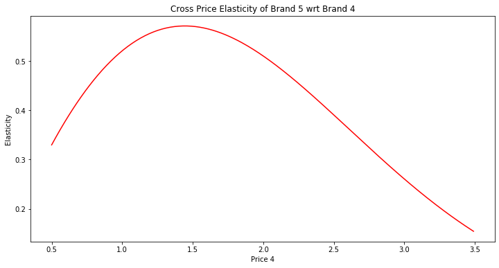

```python
plt.figure(figsize=(12,6))
plt.plot(cross_brand_5_prediction['Price_4'],brand_predict_df['cross brand 5 elasticity(i.e 4)'],color='r')
plt.xlabel('Price 4')
plt.ylabel('Elasticity')
plt.title('Cross Price Elasticity of Brand 5 wrt Brand 4')
```

## Own and Cross-Price Elasticity by Segment

## We will be esitmating it for brand 5

### Estimating Probabilty and Elasticity for Segment 3.

```python
brand_choice_3=purchase_df[purchase_df['Incidence']==1]
brand_choice_3=brand_choice_3[brand_choice_3['segment']==3]
brand_choice_3
```

|  | ID | Day | Incidence | Brand | Quantity | Last_Inc_Brand | Last_Inc_Quantity | Price_1 | Price_2 | Price_3 | ... | Promotion_5 | Sex | Marital status | Age | Education | Income | Occupation | Settlement size | segment | Mean_price |
| --- | --- | --- | --- | --- | --- | --- | --- | --- | --- | --- | --- | --- | --- | --- | --- | --- | --- | --- | --- | --- | --- |
| 376 | 200000005 | 51 | 1 | 5 | 1 | 0 | 0 | 1.35 | 1.87 | 1.93 | ... | 0 | 0 | 0 | 49 | 1 | 121466 | 1 | 2 | 3 | 1.966 |
| 377 | 200000005 | 57 | 1 | 5 | 1 | 5 | 1 | 1.39 | 1.90 | 1.91 | ... | 0 | 0 | 0 | 49 | 1 | 121466 | 1 | 2 | 3 | 1.988 |
| 394 | 200000005 | 159 | 1 | 5 | 2 | 0 | 0 | 1.39 | 1.90 | 1.94 | ... | 0 | 0 | 0 | 49 | 1 | 121466 | 1 | 2 | 3 | 2.002 |
| 396 | 200000005 | 178 | 1 | 5 | 3 | 0 | 0 | 1.48 | 1.50 | 1.99 | ... | 1 | 0 | 0 | 49 | 1 | 121466 | 1 | 2 | 3 | 1.924 |
| 410 | 200000005 | 249 | 1 | 5 | 1 | 0 | 0 | 1.46 | 1.89 | 1.99 | ... | 0 | 0 | 0 | 49 | 1 | 121466 | 1 | 2 | 3 | 2.028 |
| ... | ... | ... | ... | ... | ... | ... | ... | ... | ... | ... | ... | ... | ... | ... | ... | ... | ... | ... | ... | ... | ... |
| 57586 | 200000491 | 690 | 1 | 5 | 2 | 5 | 1 | 1.50 | 1.87 | 2.06 | ... | 0 | 0 | 0 | 35 | 1 | 150237 | 2 | 2 | 3 | 2.090 |
| 57587 | 200000491 | 697 | 1 | 5 | 5 | 5 | 1 | 1.42 | 1.51 | 1.97 | ... | 0 | 0 | 0 | 35 | 1 | 150237 | 2 | 2 | 3 | 1.984 |
| 57588 | 200000491 | 704 | 1 | 5 | 5 | 5 | 1 | 1.41 | 1.85 | 2.01 | ... | 0 | 0 | 0 | 35 | 1 | 150237 | 2 | 2 | 3 | 2.060 |
| 57589 | 200000491 | 714 | 1 | 5 | 1 | 5 | 1 | 1.50 | 1.80 | 2.09 | ... | 0 | 0 | 0 | 35 | 1 | 150237 | 2 | 2 | 3 | 2.084 |
| 57590 | 200000491 | 718 | 1 | 5 | 5 | 5 | 1 | 1.50 | 1.80 | 2.14 | ... | 0 | 0 | 0 | 35 | 1 | 150237 | 2 | 2 | 3 | 2.086 |

4381 rows × 26 columns

```python
x=brand_choice_3[['Price_1','Price_2','Price_3','Price_4','Price_5']]
x
```

|  | Price_1 | Price_2 | Price_3 | Price_4 | Price_5 |
| --- | --- | --- | --- | --- | --- |
| 376 | 1.35 | 1.87 | 1.93 | 2.09 | 2.59 |
| 377 | 1.39 | 1.90 | 1.91 | 2.12 | 2.62 |
| 394 | 1.39 | 1.90 | 1.94 | 2.16 | 2.62 |
| 396 | 1.48 | 1.50 | 1.99 | 2.16 | 2.49 |
| 410 | 1.46 | 1.89 | 1.99 | 2.15 | 2.65 |
| ... | ... | ... | ... | ... | ... |
| 57586 | 1.50 | 1.87 | 2.06 | 2.24 | 2.78 |
| 57587 | 1.42 | 1.51 | 1.97 | 2.24 | 2.78 |
| 57588 | 1.41 | 1.85 | 2.01 | 2.24 | 2.79 |
| 57589 | 1.50 | 1.80 | 2.09 | 2.24 | 2.79 |
| 57590 | 1.50 | 1.80 | 2.14 | 2.24 | 2.75 |

4381 rows × 5 columns

```python
y=brand_choice_3['Brand']
y
```

```
376      5
377      5
394      5
396      5
410      5
        ..
57586    5
57587    5
57588    5
57589    5
57590    5
Name: Brand, Length: 4381, dtype: int64
```

```python
brand_choice_3_model=LogisticRegression(solver='saga',multi_class="multinomial")
```

```python
brand_choice_3_model.fit(x,y)
```

```
LogisticRegression(C=1.0, class_weight=None, dual=False, fit_intercept=True,
                   intercept_scaling=1, l1_ratio=None, max_iter=100,
                   multi_class='multinomial', n_jobs=None, penalty='l2',
                   random_state=None, solver='saga', tol=0.0001, verbose=0,
                   warm_start=False)
```

```python
brand_choice_3_model.coef_
```

```
array([[-2.3928821 ,  0.73302405,  1.11665678,  0.02719262, -0.01343288],
       [ 1.17141125, -1.62978284,  0.27664755,  0.71171663, -0.13809165],
       [ 1.18487443, -0.04079406,  0.0668582 ,  0.18048295,  0.03870224],
       [ 0.09868166,  0.4487304 , -1.44082041, -0.96670018,  0.5944219 ],
       [-0.06208524,  0.48882246, -0.01934212,  0.04730798, -0.4815996 ]])
```

```python
coef=pd.DataFrame(brand_choice_3_model.coef_)
coef=coef.rename(columns={0:'price1',1:'price2',2:'price3',3:'price4',4:'price5'})
coef['Brand']=['brand1','brand2','brand3','brand4','brand5']
coef=coef.set_index('Brand')
coef
```

| Brand | price1 | price2 | price3 | price4 | price5 |
| --- | --- | --- | --- | --- | --- |
| brand1 | -2.392882 | 0.733024 | 1.116657 | 0.027193 | -0.013433 |
| brand2 | 1.171411 | -1.629783 | 0.276648 | 0.711717 | -0.138092 |
| brand3 | 1.184874 | -0.040794 | 0.066858 | 0.180483 | 0.038702 |
| brand4 | 0.098682 | 0.448730 | -1.440820 | -0.966700 | 0.594422 |
| brand5 | -0.062085 | 0.488822 | -0.019342 | 0.047308 | -0.481600 |

## Own-Brand Price Elasticity

```python
beta5=coef.iloc[4,4]
beta5
```

```
-0.4815996006312425
```

```python
brand_5_prediction_s3=pd.DataFrame(index=np.arange(price_range.size))
brand_5_prediction_s3['Price_1']=brand_choice_3['Price_1'].mean()
brand_5_prediction_s3['Price_2']=brand_choice_3['Price_2'].mean()
brand_5_prediction_s3['Price_3']=brand_choice_3['Price_3'].mean()
brand_5_prediction_s3['Price_4']=brand_choice_3['Price_4'].mean()
brand_5_prediction_s3['Price_5']=price_range
brand_5_prediction_s3
```

|  | Price_1 | Price_2 | Price_3 | Price_4 | Price_5 |
| --- | --- | --- | --- | --- | --- |
| 0 | 1.386222 | 1.774752 | 2.005519 | 2.158767 | 0.50 |
| 1 | 1.386222 | 1.774752 | 2.005519 | 2.158767 | 0.51 |
| 2 | 1.386222 | 1.774752 | 2.005519 | 2.158767 | 0.52 |
| 3 | 1.386222 | 1.774752 | 2.005519 | 2.158767 | 0.53 |
| 4 | 1.386222 | 1.774752 | 2.005519 | 2.158767 | 0.54 |
| ... | ... | ... | ... | ... | ... |
| 295 | 1.386222 | 1.774752 | 2.005519 | 2.158767 | 3.45 |
| 296 | 1.386222 | 1.774752 | 2.005519 | 2.158767 | 3.46 |
| 297 | 1.386222 | 1.774752 | 2.005519 | 2.158767 | 3.47 |
| 298 | 1.386222 | 1.774752 | 2.005519 | 2.158767 | 3.48 |
| 299 | 1.386222 | 1.774752 | 2.005519 | 2.158767 | 3.49 |

300 rows × 5 columns

```python
prediction=brand_choice_3_model.predict_proba(brand_5_prediction_s3)
prediction
```

```
array([[0.01682076, 0.0498538 , 0.01023813, 0.00928517, 0.91380214],
       [0.01689286, 0.05000513, 0.01028738, 0.00938183, 0.9134328 ],
       [0.01696524, 0.05015681, 0.01033684, 0.00947947, 0.91306164],
       ...,
       [0.04845035, 0.09916488, 0.03442854, 0.1626618 , 0.65529442],
       [0.04855594, 0.09925718, 0.03452156, 0.16401021, 0.65365511],
       [0.04866098, 0.09934799, 0.03461429, 0.16536717, 0.65200957]])
```

```python
seg_brand_predict_df=prediction[:,4]
seg_brand_predict_df=pd.DataFrame(seg_brand_predict_df)
seg_brand_predict_df=seg_brand_predict_df.rename(columns={0:"segmemnt 3 own brand 5 prob"})
seg_brand_predict_df
```

|  | segmemnt 3 own brand 5 prob |
| --- | --- |
| 0 | 0.913802 |
| 1 | 0.913433 |
| 2 | 0.913062 |
| 3 | 0.912689 |
| 4 | 0.912314 |
| ... | ... |
| 295 | 0.658554 |
| 296 | 0.656927 |
| 297 | 0.655294 |
| 298 | 0.653655 |
| 299 | 0.652010 |

300 rows × 1 columns

```python
pe=beta5*brand_5_prediction_s3['Price_5']*(1-seg_brand_predict_df["segmemnt 3 own brand 5 prob"])
seg_brand_predict_df['segment 3 own brand 5 elasticity']=pe
seg_brand_predict_df
```

|  | segmemnt 3 own brand 5 prob | segment 3 own brand 5 elasticity |
| --- | --- | --- |
| 0 | 0.913802 | -0.020756 |
| 1 | 0.913433 | -0.021262 |
| 2 | 0.913062 | -0.021772 |
| 3 | 0.912689 | -0.022286 |
| 4 | 0.912314 | -0.022804 |
| ... | ... | ... |
| 295 | 0.658554 | -0.567318 |
| 296 | 0.656927 | -0.571674 |
| 297 | 0.655294 | -0.576055 |
| 298 | 0.653655 | -0.580462 |
| 299 | 0.652010 | -0.584896 |

300 rows × 2 columns

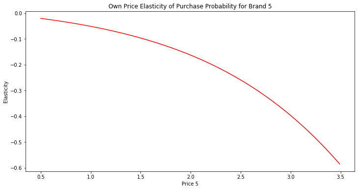

```python
plt.figure(figsize=(12,6))
plt.plot(brand_5_prediction_s3['Price_5'],seg_brand_predict_df['segment 3 own brand 5 elasticity'],color='r')
plt.xlabel('Price 5')
plt.ylabel('Elasticity')
plt.title('Own Price Elasticity of Purchase Probability for Brand 5')
```

## Cross-Brand Price Elasticity

```python
beta5=coef.iloc[4,4]
beta5
```

```
-0.4815996006312425
```

```python
cross_brand_5_prediction_s3=pd.DataFrame(index=np.arange(price_range.size))
cross_brand_5_prediction_s3['Price_1']=brand_choice_3['Price_1'].mean()
cross_brand_5_prediction_s3['Price_2']=brand_choice_3['Price_2'].mean()
cross_brand_5_prediction_s3['Price_3']=brand_choice_3['Price_3'].mean()
cross_brand_5_prediction_s3['Price_4']=price_range
cross_brand_5_prediction_s3['Price_5']=brand_choice_3['Price_5'].mean()
cross_brand_5_prediction_s3
```

|  | Price_1 | Price_2 | Price_3 | Price_4 | Price_5 |
| --- | --- | --- | --- | --- | --- |
| 0 | 1.386222 | 1.774752 | 2.005519 | 0.50 | 2.651093 |
| 1 | 1.386222 | 1.774752 | 2.005519 | 0.51 | 2.651093 |
| 2 | 1.386222 | 1.774752 | 2.005519 | 0.52 | 2.651093 |
| 3 | 1.386222 | 1.774752 | 2.005519 | 0.53 | 2.651093 |
| 4 | 1.386222 | 1.774752 | 2.005519 | 0.54 | 2.651093 |
| ... | ... | ... | ... | ... | ... |
| 295 | 1.386222 | 1.774752 | 2.005519 | 3.45 | 2.651093 |
| 296 | 1.386222 | 1.774752 | 2.005519 | 3.46 | 2.651093 |
| 297 | 1.386222 | 1.774752 | 2.005519 | 3.47 | 2.651093 |
| 298 | 1.386222 | 1.774752 | 2.005519 | 3.48 | 2.651093 |
| 299 | 1.386222 | 1.774752 | 2.005519 | 3.49 | 2.651093 |

300 rows × 5 columns

```python
prediction=brand_choice_3_model.predict_proba(cross_brand_5_prediction_s3)
prediction
```

```
array([[0.03118988, 0.02271342, 0.01646889, 0.33098994, 0.59863787],
       [0.03128284, 0.02293759, 0.01654332, 0.32869332, 0.60054293],
       [0.0313753 , 0.02316341, 0.01661767, 0.32640453, 0.60243909],
       ...,
       [0.03530638, 0.19636245, 0.02939179, 0.01957389, 0.71936548],
       [0.03525896, 0.19744565, 0.02939734, 0.01935428, 0.71854377],
       [0.03521127, 0.19853295, 0.02940262, 0.01913695, 0.71771621]])
```

```python
seg_brand_predict_df['segmemnt 3 cross brand 5 prob']=prediction[:,3]
seg_brand_predict_df
```

|  | segmemnt 3 own brand 5 prob | segment 3 own brand 5 elasticity | segmemnt 3 cross brand 5 prob |
| --- | --- | --- | --- |
| 0 | 0.913802 | -0.020756 | 0.330990 |
| 1 | 0.913433 | -0.021262 | 0.328693 |
| 2 | 0.913062 | -0.021772 | 0.326405 |
| 3 | 0.912689 | -0.022286 | 0.324124 |
| 4 | 0.912314 | -0.022804 | 0.321851 |
| ... | ... | ... | ... |
| 295 | 0.658554 | -0.567318 | 0.020020 |
| 296 | 0.656927 | -0.571674 | 0.019796 |
| 297 | 0.655294 | -0.576055 | 0.019574 |
| 298 | 0.653655 | -0.580462 | 0.019354 |
| 299 | 0.652010 | -0.584896 | 0.019137 |

300 rows × 3 columns

```python
pe=-beta5*cross_brand_5_prediction_s3['Price_4']*seg_brand_predict_df['segmemnt 3 cross brand 5 prob']
seg_brand_predict_df['segment 3 cross brand 5 elasticity']=pe
seg_brand_predict_df
```

|  | segmemnt 3 own brand 5 prob | segment 3 own brand 5 elasticity | segmemnt 3 cross brand 5 prob | segment 3 cross brand 5 elasticity |
| --- | --- | --- | --- | --- |
| 0 | 0.913802 | -0.020756 | 0.330990 | 0.079702 |
| 1 | 0.913433 | -0.021262 | 0.328693 | 0.080732 |
| 2 | 0.913062 | -0.021772 | 0.326405 | 0.081742 |
| 3 | 0.912689 | -0.022286 | 0.324124 | 0.082732 |
| 4 | 0.912314 | -0.022804 | 0.321851 | 0.083702 |
| ... | ... | ... | ... | ... |
| 295 | 0.658554 | -0.567318 | 0.020020 | 0.033264 |
| 296 | 0.656927 | -0.571674 | 0.019796 | 0.032986 |
| 297 | 0.655294 | -0.576055 | 0.019574 | 0.032711 |
| 298 | 0.653655 | -0.580462 | 0.019354 | 0.032437 |
| 299 | 0.652010 | -0.584896 | 0.019137 | 0.032165 |

300 rows × 4 columns

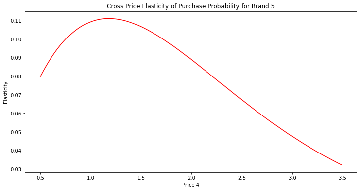

```python
plt.figure(figsize=(12,6))
plt.plot(cross_brand_5_prediction_s3['Price_4'],seg_brand_predict_df['segment 3 cross brand 5 elasticity'],color='r')
plt.xlabel('Price 4')
plt.ylabel('Elasticity')
plt.title('Cross Price Elasticity of Purchase Probability for Brand 5')
```

### Estimating Probabilty and Elasticity for Segment 2.

```python
brand_choice_2=purchase_df[purchase_df['Incidence']==1]
brand_choice_2=brand_choice_2[brand_choice_2['segment']==2]
x=brand_choice_2[['Price_1','Price_2','Price_3','Price_4','Price_5']]
y=brand_choice_2['Brand']
brand_choice_2_model=LogisticRegression(solver='saga',multi_class="multinomial")
brand_choice_2_model.fit(x,y)
coef=pd.DataFrame(brand_choice_2_model.coef_)
beta5=coef.iloc[4,4]
```

#### Own Price Elasticity

```python
brand_5_prediction_s2=pd.DataFrame(index=np.arange(price_range.size))
brand_5_prediction_s2['Price_1']=brand_choice_2['Price_1'].mean()
brand_5_prediction_s2['Price_2']=brand_choice_2['Price_2'].mean()
brand_5_prediction_s2['Price_3']=brand_choice_2['Price_3'].mean()
brand_5_prediction_s2['Price_4']=brand_choice_2['Price_4'].mean()
brand_5_prediction_s2['Price_5']=price_range
```

```python
prediction=brand_choice_2_model.predict_proba(brand_5_prediction_s2)
seg_brand_predict_df['segmemnt 2 own brand 5 prob']=prediction[:,4]
```

```python
pe=beta5*brand_5_prediction_s2['Price_5']*(1-seg_brand_predict_df["segmemnt 2 own brand 5 prob"])
seg_brand_predict_df['segment 2 own brand 5 elasticity']=pe
```

#### Cross Price Elasticity

```python
cross_brand_5_prediction_s2=pd.DataFrame(index=np.arange(price_range.size))
cross_brand_5_prediction_s2['Price_1']=brand_choice_2['Price_1'].mean()
cross_brand_5_prediction_s2['Price_2']=brand_choice_2['Price_2'].mean()
cross_brand_5_prediction_s2['Price_3']=brand_choice_2['Price_3'].mean()
cross_brand_5_prediction_s2['Price_4']=price_range
cross_brand_5_prediction_s2['Price_5']=brand_choice_2['Price_5'].mean()
```

```python
prediction=brand_choice_2_model.predict_proba(cross_brand_5_prediction_s2)
seg_brand_predict_df['segmemnt 2 cross brand 5 prob']=prediction[:,3]
```

```python
pe=-beta5*cross_brand_5_prediction_s2['Price_4']*seg_brand_predict_df['segmemnt 2 cross brand 5 prob']
seg_brand_predict_df['segment 2 cross brand 5 elasticity']=pe
```

### Estimating Probabilty and Elasticity for Segment 1.

```python
brand_choice_1=purchase_df[purchase_df['Incidence']==1]
brand_choice_1=brand_choice_1[brand_choice_1['segment']==1]
x=brand_choice_1[['Price_1','Price_2','Price_3','Price_4','Price_5']]
y=brand_choice_1['Brand']
brand_choice_1_model=LogisticRegression(solver='saga',multi_class="multinomial")
brand_choice_1_model.fit(x,y)
coef=pd.DataFrame(brand_choice_1_model.coef_)
beta5=coef.iloc[4,4]
```

#### Own Price Elasticity

```python
brand_5_prediction_s1=pd.DataFrame(index=np.arange(price_range.size))
brand_5_prediction_s1['Price_1']=brand_choice_1['Price_1'].mean()
brand_5_prediction_s1['Price_2']=brand_choice_1['Price_2'].mean()
brand_5_prediction_s1['Price_3']=brand_choice_1['Price_3'].mean()
brand_5_prediction_s1['Price_4']=brand_choice_1['Price_4'].mean()
brand_5_prediction_s1['Price_5']=price_range
```

```python
prediction=brand_choice_1_model.predict_proba(brand_5_prediction_s1)
seg_brand_predict_df['segmemnt 1 own brand 5 prob']=prediction[:,4]
```

```python
pe=beta5*brand_5_prediction_s1['Price_5']*(1-seg_brand_predict_df["segmemnt 1 own brand 5 prob"])
seg_brand_predict_df['segment 1 own brand 5 elasticity']=pe
```

#### Cross Price Elasticity

```python
cross_brand_5_prediction_s1=pd.DataFrame(index=np.arange(price_range.size))
cross_brand_5_prediction_s1['Price_1']=brand_choice_1['Price_1'].mean()
cross_brand_5_prediction_s1['Price_2']=brand_choice_1['Price_2'].mean()
cross_brand_5_prediction_s1['Price_3']=brand_choice_1['Price_3'].mean()
cross_brand_5_prediction_s1['Price_4']=price_range
cross_brand_5_prediction_s1['Price_5']=brand_choice_1['Price_5'].mean()
```

```python
prediction=brand_choice_1_model.predict_proba(cross_brand_5_prediction_s1)
seg_brand_predict_df['segmemnt 1 cross brand 5 prob']=prediction[:,3]
```

```python
pe=-beta5*cross_brand_5_prediction_s1['Price_4']*seg_brand_predict_df['segmemnt 1 cross brand 5 prob']
seg_brand_predict_df['segment 1 cross brand 5 elasticity']=pe
```

### Estimating Probabilty and Elasticity for Segment 0.

```python
brand_choice_0=purchase_df[purchase_df['Incidence']==1]
brand_choice_0=brand_choice_0[brand_choice_0['segment']==0]
x=brand_choice_0[['Price_1','Price_2','Price_3','Price_4','Price_5']]
y=brand_choice_0['Brand']
brand_choice_0_model=LogisticRegression(solver='saga',multi_class="multinomial")
brand_choice_0_model.fit(x,y)
coef=pd.DataFrame(brand_choice_0_model.coef_)
beta5=coef.iloc[4,4]
```

#### Own Price Elasticity

```python
brand_5_prediction_s0=pd.DataFrame(index=np.arange(price_range.size))
brand_5_prediction_s0['Price_1']=brand_choice_0['Price_1'].mean()
brand_5_prediction_s0['Price_2']=brand_choice_0['Price_2'].mean()
brand_5_prediction_s0['Price_3']=brand_choice_0['Price_3'].mean()
brand_5_prediction_s0['Price_4']=brand_choice_0['Price_4'].mean()
brand_5_prediction_s0['Price_5']=price_range
```

```python
prediction=brand_choice_0_model.predict_proba(brand_5_prediction_s0)
seg_brand_predict_df['segmemnt 0 own brand 5 prob']=prediction[:,4]
```

```python
pe=beta5*brand_5_prediction_s0['Price_5']*(1-seg_brand_predict_df["segmemnt 0 own brand 5 prob"])
seg_brand_predict_df['segment 0 own brand 5 elasticity']=pe
```

#### Cross Price Elasticity

```python
cross_brand_5_prediction_s0=pd.DataFrame(index=np.arange(price_range.size))
cross_brand_5_prediction_s0['Price_1']=brand_choice_0['Price_1'].mean()
cross_brand_5_prediction_s0['Price_2']=brand_choice_0['Price_2'].mean()
cross_brand_5_prediction_s0['Price_3']=brand_choice_0['Price_3'].mean()
cross_brand_5_prediction_s0['Price_4']=price_range
cross_brand_5_prediction_s0['Price_5']=brand_choice_0['Price_5'].mean()
```

```python
prediction=brand_choice_0_model.predict_proba(cross_brand_5_prediction_s0)
seg_brand_predict_df['segmemnt 0 cross brand 5 prob']=prediction[:,3]
```

```python
pe=-beta5*cross_brand_5_prediction_s0['Price_4']*seg_brand_predict_df['segmemnt 0 cross brand 5 prob']
seg_brand_predict_df['segment 0 cross brand 5 elasticity']=pe
```

```python
seg_brand_predict_df
```

|  | segmemnt 3 own brand 5 prob | segment 3 own brand 5 elasticity | segmemnt 3 cross brand 5 prob | segment 3 cross brand 5 elasticity | segmemnt 2 own brand 5 prob | segment 2 own brand 5 elasticity | segmemnt 2 cross brand 5 prob | segment 2 cross brand 5 elasticity | segmemnt 1 own brand 5 prob | segment 1 own brand 5 elasticity | segmemnt 1 cross brand 5 prob | segment 1 cross brand 5 elasticity | segmemnt 0 own brand 5 prob | segment 0 own brand 5 elasticity | segmemnt 0 cross brand 5 prob | segment 0 cross brand 5 elasticity |
| --- | --- | --- | --- | --- | --- | --- | --- | --- | --- | --- | --- | --- | --- | --- | --- | --- |
| 0 | 0.913802 | -0.020756 | 0.330990 | 0.079702 | 0.380686 | -0.090289 | 0.887172 | 0.129340 | 0.792088 | -0.117028 | 0.279825 | 0.157506 | 0.996541 | -0.004702 | 0.341126 | 0.463765 |
| 1 | 0.913433 | -0.021262 | 0.328693 | 0.080732 | 0.381195 | -0.092019 | 0.886536 | 0.131832 | 0.790644 | -0.120198 | 0.277668 | 0.159418 | 0.996426 | -0.004956 | 0.338575 | 0.469503 |
| 2 | 0.913062 | -0.021772 | 0.326405 | 0.081742 | 0.381691 | -0.093748 | 0.885896 | 0.134320 | 0.789189 | -0.123406 | 0.275519 | 0.161286 | 0.996307 | -0.005222 | 0.336031 | 0.475112 |
| 3 | 0.912689 | -0.022286 | 0.324124 | 0.082732 | 0.382174 | -0.095477 | 0.885253 | 0.136804 | 0.787722 | -0.126655 | 0.273378 | 0.163110 | 0.996183 | -0.005500 | 0.333495 | 0.480594 |
| 4 | 0.912314 | -0.022804 | 0.321851 | 0.083702 | 0.382643 | -0.097204 | 0.884606 | 0.139283 | 0.786243 | -0.129944 | 0.271245 | 0.164891 | 0.996056 | -0.005791 | 0.330967 | 0.485950 |
| ... | ... | ... | ... | ... | ... | ... | ... | ... | ... | ... | ... | ... | ... | ... | ... | ... |
| 295 | 0.658554 | -0.567318 | 0.020020 | 0.033264 | 0.116809 | -0.888441 | 0.050481 | 0.050781 | 0.046778 | -3.702154 | 0.007683 | 0.029839 | 0.004286 | -9.340431 | 0.007010 | 0.065755 |
| 296 | 0.656927 | -0.571674 | 0.019796 | 0.032986 | 0.115868 | -0.891965 | 0.048737 | 0.049169 | 0.045837 | -3.716551 | 0.007560 | 0.029445 | 0.004119 | -9.369081 | 0.006865 | 0.064581 |
| 297 | 0.655294 | -0.576055 | 0.019574 | 0.032711 | 0.114933 | -0.895490 | 0.047048 | 0.047602 | 0.044912 | -3.730905 | 0.007438 | 0.029056 | 0.003958 | -9.397678 | 0.006722 | 0.063422 |
| 298 | 0.653655 | -0.580462 | 0.019354 | 0.032437 | 0.114003 | -0.899013 | 0.045411 | 0.046078 | 0.044004 | -3.745215 | 0.007319 | 0.028671 | 0.003803 | -9.426226 | 0.006582 | 0.062280 |
| 299 | 0.652010 | -0.584896 | 0.019137 | 0.032165 | 0.113080 | -0.902536 | 0.043825 | 0.044597 | 0.043112 | -3.759481 | 0.007201 | 0.028291 | 0.003654 | -9.454724 | 0.006444 | 0.061154 |

300 rows × 16 columns